# Diversity project tissue cleanup

2025-05-18

### Cleaning up and pre-processing

We begin by taking a quick look at the tissue type descriptors to get some numbers… Some of these clearly do not contain cell type info, but others do, and sorting those out is joyous.

```r
table(allSRAFinal$Cell_type) # Useful
```

```
##
##                            adipose-derived stromal cells (hASCs)                                          aortic endothelial cell
##                                                               54                                                                4
##                                          Aortic enothelial cells                                                          B cells
##                                                                3                                                               29
##                                                     B-Lymphocyte                                               BBB microvascaular
##                                                               30                                                               29
##                                                 blood leukocytes                                                    breast cancer
##                                                               12                                                               33
##                                              Cardiac fibroblasts                                                    cardiomyocyte
##                                                              166                                                               12
##                                 Carotid artery endothelial cells                                             CD138-negative cells
##                                                                6                                                               10
##                                             CD138-positive cells                                      CD14+ peripheral blood cell
##                                                               10                                                                4
##                                                            CD19+                             CD34+ sorted bone marrow progenitors
##                                                               23                                                               12
##                                                       CD4 T cell                                                      CD4 T cells
##                                                               10                                                               79
##                                                     CD4+ T cells                                      CD56+ peripheral blood cell
##                                                               42                                                                4
##                                                       CD8 T cell                                                      CD8 T cells
##                                                                8                                                               53
##                                                      CD8+ T cell                                                              cDC
##                                                               22                                                               29
##                                     CELL MIXTURE - tissue sample                                               classical monocyte
##                                                                1                                                               34
##                                 CLEAR CELL ADENOCARCINOMA\\, NOS                                                              cMo
##                                                                1                                                              110
##                                     cord blood mononuclear cells                                Coronary artery endothelial cells
##                                                               30                                                                4
##                                                 endocardial cell                                                Endocardial cells
##                                                                1                                                                3
##                                      ENDOMETRIOID ADENOCARCINOMA                      endothelial cell of artery (common carotid)
##                                                                1                                                                8
##                         endothelial cell of great saphenous vein                             endothelial cell of umbilical artery
##                                                                3                                                                1
##                                                Endothelial cells                                                       epithelial
##                                                               48                                                               60
##                                                       Epithelial                                                       fibroblast
```

[output cut: 62 more lines]

```
##                                                                2                                                                7
##                                            SEROUS ADENOCARCINOMA                                                 SEROUS CARCINOMA
##                                                                2                                                                4
##                               SEROUS SURFACE PAPILLARY CARCINOMA                            Small Airway Epithelial Cells (SAECs)
##                                                                3                                                               36
##                                                        Stem Cell                             superior vena cava endothelial cells
##                                                                8                                                                1
##                                                           T cell                                                          T cells
##                                                               18                                                               33
##                                                              Tfh                                                             Treg
##                                                               74                                                               74
##                               Umbilical artery endothelial cells                                 Umbilical vein endothelial cells
##                                                                2                                                                3
##                                                White blood cells                                                      Whole blood
##                                                               67                                                               28
```

```r
table(allSRAFinal$Tissue) # Useful
```

```
##
##                                                                           AC                                                                   ACD plasma
##                                                                           18                                                                           12
##                                                 Adenocarcinoma of the kidney                                        Adenocarcinoma of the large intestine
##                                                                            1                                                                            2
##                                                   Adenocarcinoma of the lung                                                   Adenocarcinoma\\, invasive
##                                                                            2                                                                            2
##                                       Adenocarcinoma\\, invasive of the lung                                              Adenocarcinoma\\, mixed subtype
##                                                                            1                                                                            1
##                                      Adenocarcinoma\\, papillary predominant                                                                      adipose
##                                                                            1                                                                           50
##                                                       Adjacent normal tissue                                                                      Adrenal
##                                                                           14                                                                            1
##                                                              adult cartilage                                                                        Aorta
##                                                                            3                                                                           51
##                                                        Apical left ventricle                                                                Atrial Tissue
##                                                                           32                                                                           24
##                                                            autonomic_ganglia                                                               Base of Tongue
##                                                                           16                                                                           10
##                                                                biliary_tract                                                                          BLA
##                                                                            8                                                                           60
##                                                                      bladder                                                               Bladder cancer
##                                                                            1                                                                            5
##                                                                        blood                                                                        Blood
##                                                                         4870                                                                         1287
##                             blood plasma enriched for extracellular vesicles                                                                         bone
```

[output cut: 217 more lines]

```r
table(allSRAFinal$tissue_type) # Useful
```

```
##
##                          Adipose                   Adipose Tissue                    Adrenal Gland                            Aorta                          Bladder
##                                2                                1                                2                                2                                1
##                        Esophagus                          Gastric                   Left Ventricle                            Liver                             Lung
##                                2                                3                                2                                1                                2
##                            Ovary                         Pancreas                     Psoas Muscle                     Right Atrium                  Right Ventricle
##                                1                                2                                3                                1                                2
##                    Sigmoid Colon                  Small Intestine                           Spleen the endothelium of blood vessels                           Thymus
##                                3                                3                                3                               26                                1
```

```r
table(allSRAFinal$Sample_type) # Somewhat useful
```

```
##
##                 blood tissue sample                        cell culture                        Cell culture Cell Culture Transcriptome Sequence               hiPSC-derived neurons
##                                  16                                1030                                  24                                  29                                  28
##                           leukocyte      Plasma sample\\, platelet-poor                        Primary Cell                        Serum sample                       the cirrhotic
##                                  12                                  68                                  42                                  12                                   9
##                   the liver tissues                              Tissue                       tissue sample
##                                   9                                   6                                  15
```

```r
table(allSRAFinal$Sample.Name) # Nope
```

```
## < table of extent 0 >
```

```r
table(allSRAFinal$source_name) # Useful
```

```
##
##                                                                                 12-cell blastomere
##                                                                                                  6
##                                                                                 16-cell blastomere
##                                                                                                  7
##                                                                                  4 mm punch biopsy
##                                                                                                 16
##                                                                                  4-cell blastomere
##                                                                                                  5
##                                                                                  8-cell blastomere
##                                                                                                 23
##                                                                                    Active_Baseline
##                                                                                                 29
##                                                                                         Active_M30
##                                                                                                  2
##                                                                                      Active_Wk 104
##                                                                                                 18
##                                                                                Active_Wk 104 (130)
##                                                                                                  1
##                                                                             Active_Wk 104 (or M30)
##                                                                                                  1
##                                                                                       Active_Wk 26
##                                                                                                 28
##                                                                                       Active_Wk 52
##                                                                                                 30
##                                                                                       Active_Wk 78
##                                                                                                 26
##                                                                                            adipose
##                                                                                                 50
##                                                                        Aged A_peripheral blood HSC
##                                                                                                 94
##                                                                        Aged B_peripheral blood HSC
##                                                                                                 83
##                                                                        Aged C_peripheral blood HSC
##                                                                                                 94
##                                                                        Aged D_peripheral blood HSC
##                                                                                                 94
##                                                                       Air Liquid Interface culture
##                                                                                                 36
##                                                                              AnCg_Bipolar Disorder
```

[output cut: 676 more lines]

```
##                                                                                                232
##                                                                   Whole blood_activity_tertile_one
##                                                                                                  7
##                                                                 Whole blood_activity_tertile_three
##                                                                                                  5
##                                                                   Whole blood_activity_tertile_two
##                                                                                                  9
##                                                                          Yg A_peripheral blood HSC
##                                                                                                 94
##                                                                          Yg B_peripheral blood HSC
##                                                                                                 83
##                                                                          Yg C_peripheral blood HSC
##                                                                                                 94
##                                                                          Yg D_peripheral blood HSC
##                                                                                                 94
```

```r
table(allSRAFinal$source_material_cell_type) # goes with the next column
```

```
##
## Fibroblast
##        332
```

```r
table(allSRAFinal$source_material) #
```

```
##
## Skin tissue
##         332
```

```r
table(allSRAFinal$SAMPLE_TYPE) # Somewhat useful
```

```
##
##                                12-cell blastomere                                16-cell blastomere                                 4-cell blastomere
##                                                 6                                                 7                                                 5
##                                 8-cell blastomere                                              cell                                      cell culture
##                                                23                                                12                                               184
##                                      Cell Culture                 Cell culture Biological Replica 1                 Cell culture Biological Replica 2
##                                                48                                                 7                                                 7
##                 Cell culture Biological Replica 3               Day 0 Biological Replicate A WTC-11               Day 0 Biological Replicate B WTC-11
##                                                 7                                                 1                                                 1
##               Day 0 Biological Replicate C WTC-11              Day 13 Biological Replicate A WTC-11              Day 13 Biological Replicate B WTC-11
##                                                 1                                                 1                                                 1
##              Day 13 Biological Replicate C WTC-11              Day 18 Biological Replicate A WTC-11              Day 18 Biological Replicate B WTC-11
##                                                 1                                                 1                                                 1
##              Day 18 Biological Replicate C WTC-11              Day 28 Biological Replicate A WTC-11              Day 28 Biological Replicate B WTC-11
##                                                 1                                                 1                                                 1
##              Day 28 Biological Replicate C WTC-11               Day 7 Biological Replicate A WTC-11               Day 7 Biological Replicate B WTC-11
##                                                 1                                                 1                                                 1
##               Day 7 Biological Replicate C WTC-11                               DNA-seq and RNA-seq                                              FFPE
##                                                 1                                                16                                                17
##                                   inner cell mass                  iPSC- derived cerebral organoids                           iPSC-derived cell types
##                                                13                                                24                                               304
## Laser Capture Microdissection followed by RNA-seq                                         leukocyte                                          organoid
##                                               258                                                32                                                39
##                                   PBMC from blood                                     polysomal RNA                                       Post-mortem
##                                                36                                                 6                                                20
##                                          Resected                                               RNA                                           RNA-seq
##                                                30                                                82                                                 8
##                                       single cell                                            Tissue                        tissue cytological samples
##                                                47                                                38                                                17
##                                     tissue sample                                         total RNA                                     trophectoderm
##                                              1040                                                 6                                                 9
##                                       whole blood                                       Whole Blood
##                                                60                                                56
```

```r
table(allSRAFinal$Sampling_site) # A single study once again...
```

```
##
##  adrenal gland      bile duct        bladder           bone          brain         breast     chest wall          colon    endometrium         kidney          liver           lung
##              1              2             16              1              1             15              3              1              1              1              4             33
##     lymph node         muscle        omentum          other          ovary       pancreas pleural cavity           skin    soft tissue
##             11              1              2              1              1              3              2              1              4
```

```r
# The most useful ones are gonna be Tissue, Cell_type and source_name, I think
(table(is.na(allSRAFinal$Tissue), is.na(allSRAFinal$Cell_type)))
```

```
##
##         FALSE  TRUE
##   FALSE  2535 13829
##   TRUE   2298  6586
```

```r
head(allSRAFinal[!is.na(allSRAFinal$Tissue) & !is.na(allSRAFinal$Cell_type), ])
```

```
##       SRA.Study Center.Name    BioSample     Organism  LibrarySource Cell_type Tissue Cell_line disease ETHNICITY disease_state Diagnosis tissue_type clinical_information
## 58488 SRP166898         GEO SAMN10315825 Homo sapiens TRANSCRIPTOMIC       Tfh   PBMC      <NA>    <NA>      <NA>          <NA>      <NA>        <NA>                 <NA>
## 58489 SRP166898         GEO SAMN10315821 Homo sapiens TRANSCRIPTOMIC       Tfh   PBMC      <NA>    <NA>      <NA>          <NA>      <NA>        <NA>                 <NA>
## 58490 SRP166898         GEO SAMN10315820 Homo sapiens TRANSCRIPTOMIC       Tfh   PBMC      <NA>    <NA>      <NA>          <NA>      <NA>        <NA>                 <NA>
## 58491 SRP166898         GEO SAMN10315934 Homo sapiens TRANSCRIPTOMIC       Tfh   PBMC      <NA>    <NA>      <NA>          <NA>      <NA>        <NA>                 <NA>
## 58492 SRP166898         GEO SAMN10315933 Homo sapiens TRANSCRIPTOMIC       Tfh   PBMC      <NA>    <NA>      <NA>          <NA>      <NA>        <NA>                 <NA>
## 58493 SRP166898         GEO SAMN10315931 Homo sapiens TRANSCRIPTOMIC       Tfh   PBMC      <NA>    <NA>      <NA>          <NA>      <NA>        <NA>                 <NA>
##                            RACE health_state Population DONOR_HEALTH_STATUS DONOR_ETHNICITY reported_race ReleaseDate         create_date ancestry donor_id Sample_type source_name
## 58488                     White         <NA>       <NA>                <NA>            <NA>          <NA>  2018-12-27 2018-10-25 17:04:00     <NA>     <NA>        <NA>        PBMC
## 58489                     White         <NA>       <NA>                <NA>            <NA>          <NA>  2018-12-27 2018-10-25 17:04:00     <NA>     <NA>        <NA>        PBMC
## 58490                     White         <NA>       <NA>                <NA>            <NA>          <NA>  2018-12-27 2018-10-25 17:04:00     <NA>     <NA>        <NA>        PBMC
## 58491 Black or African American         <NA>       <NA>                <NA>            <NA>          <NA>  2018-12-27 2018-10-25 17:04:00     <NA>     <NA>        <NA>        PBMC
## 58492 Black or African American         <NA>       <NA>                <NA>            <NA>          <NA>  2018-12-27 2018-10-25 17:04:00     <NA>     <NA>        <NA>        PBMC
## 58493                     White         <NA>       <NA>                <NA>            <NA>          <NA>  2018-12-27 2018-10-25 17:04:00     <NA>     <NA>        <NA>        PBMC
##       source_material_cell_type source_material Organism_part race.ethnicity primary_race SAMPLE_TYPE Sampling_site                 finalRace finalGeography hispanic
## 58488                      <NA>            <NA>          <NA>           <NA>         <NA>        <NA>          <NA>                     White           <NA>     <NA>
## 58489                      <NA>            <NA>          <NA>           <NA>         <NA>        <NA>          <NA>                     White           <NA>     <NA>
## 58490                      <NA>            <NA>          <NA>           <NA>         <NA>        <NA>          <NA>                     White           <NA>     <NA>
## 58491                      <NA>            <NA>          <NA>           <NA>         <NA>        <NA>          <NA> Black or African American           <NA>     <NA>
## 58492                      <NA>            <NA>          <NA>           <NA>         <NA>        <NA>          <NA> Black or African American           <NA>     <NA>
## 58493                      <NA>            <NA>          <NA>           <NA>         <NA>        <NA>          <NA>                     White           <NA>     <NA>
```

```r
(table(is.na(allSRAFinal$Tissue), is.na(allSRAFinal$source_name)))
```

```
##
##         FALSE TRUE
##   FALSE  7291 9073
##   TRUE   7132 1752
```

```r
head(allSRAFinal[!is.na(allSRAFinal$Tissue) & !is.na(allSRAFinal$source_name), ])
```

```
##       SRA.Study Center.Name    BioSample     Organism  LibrarySource Cell_type   Tissue Cell_line disease ETHNICITY disease_state Diagnosis tissue_type clinical_information
## 48644 SRP043166         GEO SAMN02852956 Homo sapiens TRANSCRIPTOMIC      <NA> Pterygia      <NA>    <NA>      <NA>          <NA>      <NA>        <NA>                 <NA>
## 48645 SRP043166         GEO SAMN02852957 Homo sapiens TRANSCRIPTOMIC      <NA> Pterygia      <NA>    <NA>      <NA>          <NA>      <NA>        <NA>                 <NA>
## 48646 SRP043166         GEO SAMN02852961 Homo sapiens TRANSCRIPTOMIC      <NA> Pterygia      <NA>    <NA>      <NA>          <NA>      <NA>        <NA>                 <NA>
## 48647 SRP043166         GEO SAMN02852955 Homo sapiens TRANSCRIPTOMIC      <NA> Pterygia      <NA>    <NA>      <NA>          <NA>      <NA>        <NA>                 <NA>
## 48648 SRP043166         GEO SAMN02852959 Homo sapiens TRANSCRIPTOMIC      <NA> Pterygia      <NA>    <NA>      <NA>          <NA>      <NA>        <NA>                 <NA>
## 48649 SRP043166         GEO SAMN02852964 Homo sapiens TRANSCRIPTOMIC      <NA> Pterygia      <NA>    <NA>      <NA>          <NA>      <NA>        <NA>                 <NA>
##            RACE health_state Population DONOR_HEALTH_STATUS DONOR_ETHNICITY reported_race ReleaseDate         create_date ancestry donor_id Sample_type source_name
## 48644 Caucasian         <NA>       <NA>                <NA>            <NA>          <NA>  2015-07-22 2015-12-09 02:16:00     <NA>     <NA>        <NA>   Pterygium
## 48645 Caucasian         <NA>       <NA>                <NA>            <NA>          <NA>  2015-07-22 2015-12-09 02:16:00     <NA>     <NA>        <NA>   Pterygium
## 48646 Caucasian         <NA>       <NA>                <NA>            <NA>          <NA>  2015-07-22 2015-12-09 02:16:00     <NA>     <NA>        <NA>   Pterygium
## 48647 Caucasian         <NA>       <NA>                <NA>            <NA>          <NA>  2015-07-22 2015-12-09 02:15:00     <NA>     <NA>        <NA>   Pterygium
## 48648 Caucasian         <NA>       <NA>                <NA>            <NA>          <NA>  2015-07-22 2015-12-09 02:16:00     <NA>     <NA>        <NA>   Pterygium
## 48649 Caucasian         <NA>       <NA>                <NA>            <NA>          <NA>  2015-07-22 2015-12-09 01:31:00     <NA>     <NA>        <NA>   Pterygium
##       source_material_cell_type source_material Organism_part race.ethnicity primary_race SAMPLE_TYPE Sampling_site finalRace finalGeography hispanic
## 48644                      <NA>            <NA>          <NA>           <NA>         <NA>        <NA>          <NA>     White           <NA>     <NA>
## 48645                      <NA>            <NA>          <NA>           <NA>         <NA>        <NA>          <NA>     White           <NA>     <NA>
## 48646                      <NA>            <NA>          <NA>           <NA>         <NA>        <NA>          <NA>     White           <NA>     <NA>
## 48647                      <NA>            <NA>          <NA>           <NA>         <NA>        <NA>          <NA>     White           <NA>     <NA>
## 48648                      <NA>            <NA>          <NA>           <NA>         <NA>        <NA>          <NA>     White           <NA>     <NA>
## 48649                      <NA>            <NA>          <NA>           <NA>         <NA>        <NA>          <NA>     White           <NA>     <NA>
```

```r
(table(is.na(allSRAFinal$Cell_type), is.na(allSRAFinal$source_name)))
```

```
##
##         FALSE  TRUE
##   FALSE  2804  2029
##   TRUE  11619  8796
```

```r
head(allSRAFinal[!is.na(allSRAFinal$Cell_type) & !is.na(allSRAFinal$source_name), ])
```

```
##       SRA.Study Center.Name    BioSample     Organism  LibrarySource           Cell_type Tissue Cell_line disease ETHNICITY disease_state Diagnosis tissue_type
## 48582 SRP120018         GEO SAMN07789039 Homo sapiens TRANSCRIPTOMIC             HepLPCs   <NA>      <NA>    <NA>     Asian          <NA>      <NA>        <NA>
## 48583 SRP120018         GEO SAMN07789036 Homo sapiens TRANSCRIPTOMIC Primary hepatocytes   <NA>      <NA>    <NA>     Asian          <NA>      <NA>        <NA>
## 48656 SRP120018         GEO SAMN07789049 Homo sapiens TRANSCRIPTOMIC         HepLPCs-Hep   <NA>      <NA>    <NA>     Asian          <NA>      <NA>        <NA>
## 48657 SRP120018         GEO SAMN07789046 Homo sapiens TRANSCRIPTOMIC             HepLPCs   <NA>      <NA>    <NA>     Asian          <NA>      <NA>        <NA>
## 48658 SRP120018         GEO SAMN07789037 Homo sapiens TRANSCRIPTOMIC             HepLPCs   <NA>      <NA>    <NA>     Asian          <NA>      <NA>        <NA>
## 48659 SRP120018         GEO SAMN07789041 Homo sapiens TRANSCRIPTOMIC             HepLPCs   <NA>      <NA>    <NA>     Asian          <NA>      <NA>        <NA>
##       clinical_information RACE health_state Population DONOR_HEALTH_STATUS DONOR_ETHNICITY reported_race ReleaseDate         create_date ancestry donor_id Sample_type
## 48582                 <NA> <NA>         <NA>       <NA>                <NA>            <NA>          <NA>  2017-10-30 2017-10-24 11:32:00     <NA>     <NA>        <NA>
## 48583                 <NA> <NA>         <NA>       <NA>                <NA>            <NA>          <NA>  2017-10-30 2017-10-16 12:24:00     <NA>     <NA>        <NA>
## 48656                 <NA> <NA>         <NA>       <NA>                <NA>            <NA>          <NA>  2017-10-30 2017-10-16 12:11:00     <NA>     <NA>        <NA>
## 48657                 <NA> <NA>         <NA>       <NA>                <NA>            <NA>          <NA>  2017-10-30 2017-10-16 12:12:00     <NA>     <NA>        <NA>
## 48658                 <NA> <NA>         <NA>       <NA>                <NA>            <NA>          <NA>  2017-10-30 2017-10-16 12:10:00     <NA>     <NA>        <NA>
## 48659                 <NA> <NA>         <NA>       <NA>                <NA>            <NA>          <NA>  2017-10-30 2017-10-16 12:05:00     <NA>     <NA>        <NA>
##               source_name source_material_cell_type source_material Organism_part race.ethnicity primary_race SAMPLE_TYPE Sampling_site finalRace finalGeography hispanic
## 48582      Donor_1 TEM P5                      <NA>            <NA>          <NA>           <NA>         <NA>        <NA>          <NA>      <NA>           Asia     <NA>
## 48583        Donor_2 PHCs                      <NA>            <NA>          <NA>           <NA>         <NA>        <NA>          <NA>      <NA>           Asia     <NA>
## 48656 Donor_1 HepLPCs-Hep                      <NA>            <NA>          <NA>           <NA>         <NA>        <NA>          <NA>      <NA>           Asia     <NA>
## 48657   Donor_1 TEM Day10                      <NA>            <NA>          <NA>           <NA>         <NA>        <NA>          <NA>      <NA>           Asia     <NA>
## 48658   Donor_2 TEM Day10                      <NA>            <NA>          <NA>           <NA>         <NA>        <NA>          <NA>      <NA>           Asia     <NA>
## 48659      Donor_2 TEM P5                      <NA>            <NA>          <NA>           <NA>         <NA>        <NA>          <NA>      <NA>           Asia     <NA>
```

```r
head(allSRAFinal[is.na(allSRAFinal$Tissue) & is.na(allSRAFinal$Cell_type), ])
```

```
##       SRA.Study Center.Name    BioSample     Organism  LibrarySource Cell_type Tissue Cell_line disease ETHNICITY disease_state Diagnosis tissue_type clinical_information
## 49372 SRP191569         GEO SAMN11372981 Homo sapiens TRANSCRIPTOMIC      <NA>   <NA>      <NA>    <NA>      <NA>          <NA>      <NA>        <NA>                 <NA>
## 49382 SRP191569         GEO SAMN11372986 Homo sapiens TRANSCRIPTOMIC      <NA>   <NA>      <NA>    <NA>      <NA>          <NA>      <NA>        <NA>                 <NA>
## 49383 SRP191569         GEO SAMN11372985 Homo sapiens TRANSCRIPTOMIC      <NA>   <NA>      <NA>    <NA>      <NA>          <NA>      <NA>        <NA>                 <NA>
## 49384 SRP191569         GEO SAMN11372984 Homo sapiens TRANSCRIPTOMIC      <NA>   <NA>      <NA>    <NA>      <NA>          <NA>      <NA>        <NA>                 <NA>
## 49385 SRP191569         GEO SAMN11372983 Homo sapiens TRANSCRIPTOMIC      <NA>   <NA>      <NA>    <NA>      <NA>          <NA>      <NA>        <NA>                 <NA>
## 49386 SRP191569         GEO SAMN11372980 Homo sapiens TRANSCRIPTOMIC      <NA>   <NA>      <NA>    <NA>      <NA>          <NA>      <NA>        <NA>                 <NA>
##                   RACE health_state Population DONOR_HEALTH_STATUS DONOR_ETHNICITY reported_race ReleaseDate         create_date ancestry donor_id Sample_type source_name
## 49372 African American         <NA>       <NA>                <NA>            <NA>          <NA>  2019-08-24 2019-04-09 14:25:00     <NA>     <NA>        <NA>       PBMCs
## 49382 African American         <NA>       <NA>                <NA>            <NA>          <NA>  2019-08-24 2019-04-09 14:21:00     <NA>     <NA>        <NA>       PBMCs
## 49383 African American         <NA>       <NA>                <NA>            <NA>          <NA>  2019-08-24 2019-04-09 14:21:00     <NA>     <NA>        <NA>       PBMCs
## 49384 African American         <NA>       <NA>                <NA>            <NA>          <NA>  2019-08-24 2019-04-09 14:21:00     <NA>     <NA>        <NA>       PBMCs
## 49385 African American         <NA>       <NA>                <NA>            <NA>          <NA>  2019-08-24 2019-04-09 14:23:00     <NA>     <NA>        <NA>       PBMCs
## 49386 African American         <NA>       <NA>                <NA>            <NA>          <NA>  2019-08-24 2019-04-09 14:22:00     <NA>     <NA>        <NA>       PBMCs
##       source_material_cell_type source_material Organism_part race.ethnicity primary_race SAMPLE_TYPE Sampling_site                 finalRace finalGeography hispanic
## 49372                      <NA>            <NA>          <NA>           <NA>         <NA>        <NA>          <NA> Black or African American           <NA>     <NA>
## 49382                      <NA>            <NA>          <NA>           <NA>         <NA>        <NA>          <NA> Black or African American           <NA>     <NA>
## 49383                      <NA>            <NA>          <NA>           <NA>         <NA>        <NA>          <NA> Black or African American           <NA>     <NA>
## 49384                      <NA>            <NA>          <NA>           <NA>         <NA>        <NA>          <NA> Black or African American           <NA>     <NA>
## 49385                      <NA>            <NA>          <NA>           <NA>         <NA>        <NA>          <NA> Black or African American           <NA>     <NA>
## 49386                      <NA>            <NA>          <NA>           <NA>         <NA>        <NA>          <NA> Black or African American           <NA>     <NA>
```

```r
head(allSRAFinal[is.na(allSRAFinal$Tissue) & is.na(allSRAFinal$Cell_type) & is.na(allSRAFinal$source_name), ])
```

```
##        SRA.Study               Center.Name    BioSample     Organism  LibrarySource Cell_type Tissue Cell_line                              disease ETHNICITY disease_state
## 188456 ERP116722 Exeter Sequencing Service SAMEA5854572 Homo sapiens TRANSCRIPTOMIC      <NA>   <NA>      <NA>                     cerebral malaria  Mandingo          <NA>
## 188457 ERP116722 Exeter Sequencing Service SAMEA5854573 Homo sapiens TRANSCRIPTOMIC      <NA>   <NA>      <NA>                     cerebral malaria      Jola          <NA>
## 188459 ERP116722 Exeter Sequencing Service SAMEA5854574 Homo sapiens TRANSCRIPTOMIC      <NA>   <NA>      <NA>                     cerebral malaria  Mandingo          <NA>
## 188460 ERP116722 Exeter Sequencing Service SAMEA5854575 Homo sapiens TRANSCRIPTOMIC      <NA>   <NA>      <NA>                     cerebral malaria     Fulla          <NA>
## 188461 ERP116722 Exeter Sequencing Service SAMEA5854576 Homo sapiens TRANSCRIPTOMIC      <NA>   <NA>      <NA>                     cerebral malaria     Fulla          <NA>
## 188463 ERP116722 Exeter Sequencing Service SAMEA5854577 Homo sapiens TRANSCRIPTOMIC      <NA>   <NA>      <NA> cerebral malaria and hyperlactatemia      Jola          <NA>
##        Diagnosis tissue_type clinical_information RACE health_state Population DONOR_HEALTH_STATUS DONOR_ETHNICITY reported_race ReleaseDate         create_date ancestry donor_id
## 188456      <NA>        <NA>                 <NA> <NA>         <NA>       <NA>                <NA>            <NA>          <NA>  2019-08-07 2022-07-24 09:35:00     <NA>     <NA>
## 188457      <NA>        <NA>                 <NA> <NA>         <NA>       <NA>                <NA>            <NA>          <NA>  2019-08-07 2021-10-10 16:52:00     <NA>     <NA>
## 188459      <NA>        <NA>                 <NA> <NA>         <NA>       <NA>                <NA>            <NA>          <NA>  2019-08-07 2021-10-10 18:19:00     <NA>     <NA>
## 188460      <NA>        <NA>                 <NA> <NA>         <NA>       <NA>                <NA>            <NA>          <NA>  2019-08-07 2022-07-18 16:45:00     <NA>     <NA>
## 188461      <NA>        <NA>                 <NA> <NA>         <NA>       <NA>                <NA>            <NA>          <NA>  2019-08-07 2021-10-10 17:04:00     <NA>     <NA>
## 188463      <NA>        <NA>                 <NA> <NA>         <NA>       <NA>                <NA>            <NA>          <NA>  2019-08-07 2022-07-15 18:32:00     <NA>     <NA>
##        Sample_type source_name source_material_cell_type source_material Organism_part race.ethnicity primary_race SAMPLE_TYPE Sampling_site finalRace    finalGeography hispanic
## 188456        <NA>        <NA>                      <NA>            <NA>         blood           <NA>         <NA>        <NA>          <NA>      <NA> Subsaharan Africa     <NA>
## 188457        <NA>        <NA>                      <NA>            <NA>         blood           <NA>         <NA>        <NA>          <NA>      <NA> Subsaharan Africa     <NA>
## 188459        <NA>        <NA>                      <NA>            <NA>         blood           <NA>         <NA>        <NA>          <NA>      <NA> Subsaharan Africa     <NA>
## 188460        <NA>        <NA>                      <NA>            <NA>         blood           <NA>         <NA>        <NA>          <NA>      <NA> Subsaharan Africa     <NA>
## 188461        <NA>        <NA>                      <NA>            <NA>         blood           <NA>         <NA>        <NA>          <NA>      <NA> Subsaharan Africa     <NA>
## 188463        <NA>        <NA>                      <NA>            <NA>         blood           <NA>         <NA>        <NA>          <NA>      <NA> Subsaharan Africa     <NA>
```

```r
dim(allSRAFinal[is.na(allSRAFinal$Tissue) & is.na(allSRAFinal$Cell_type) & is.na(allSRAFinal$source_name) & is.na(allSRAFinal$tissue_type) & is.na(allSRAFinal$Organism_part), ])
```

```
## [1] 464  36
```

```r
noInfo <- allSRAFinal[is.na(allSRAFinal$Tissue) & is.na(allSRAFinal$Cell_type) & is.na(allSRAFinal$source_name) & is.na(allSRAFinal$tissue_type) &is.na(allSRAFinal$Organism_part), ]
table(noInfo$SRA.Study)
```

```
##
## ERP001942
##       464
```

```r
by(noInfo, noInfo$SRA.Study, function(x) head(x, n=20))
```

```
## noInfo$SRA.Study: ERP001942
##        SRA.Study Center.Name    BioSample     Organism  LibrarySource Cell_type Tissue Cell_line disease ETHNICITY disease_state Diagnosis tissue_type clinical_information RACE
## 254802 ERP001942       UNIGE SAMEA1573207 Homo sapiens TRANSCRIPTOMIC      <NA>   <NA>      <NA>    <NA>      <NA>          <NA>      <NA>        <NA>                 <NA> <NA>
## 254803 ERP001942       UNIGE SAMEA1573203 Homo sapiens TRANSCRIPTOMIC      <NA>   <NA>      <NA>    <NA>      <NA>          <NA>      <NA>        <NA>                 <NA> <NA>
## 254804 ERP001942       MPIMG SAMEA1573212 Homo sapiens TRANSCRIPTOMIC      <NA>   <NA>      <NA>    <NA>      <NA>          <NA>      <NA>        <NA>                 <NA> <NA>
## 254805 ERP001942       UNIGE SAMEA1573516 Homo sapiens TRANSCRIPTOMIC      <NA>   <NA>      <NA>    <NA>      <NA>          <NA>      <NA>        <NA>                 <NA> <NA>
## 254806 ERP001942         CRG SAMEA1573527 Homo sapiens TRANSCRIPTOMIC      <NA>   <NA>      <NA>    <NA>      <NA>          <NA>      <NA>        <NA>                 <NA> <NA>
## 254807 ERP001942       MPIMG SAMEA1573339 Homo sapiens TRANSCRIPTOMIC      <NA>   <NA>      <NA>    <NA>      <NA>          <NA>      <NA>        <NA>                 <NA> <NA>
## 254808 ERP001942        LUMC SAMEA1573507 Homo sapiens TRANSCRIPTOMIC      <NA>   <NA>      <NA>    <NA>      <NA>          <NA>      <NA>        <NA>                 <NA> <NA>
## 254809 ERP001942       UNIGE SAMEA1573345 Homo sapiens TRANSCRIPTOMIC      <NA>   <NA>      <NA>    <NA>      <NA>          <NA>      <NA>        <NA>                 <NA> <NA>
## 254810 ERP001942       MPIMG SAMEA1573368 Homo sapiens TRANSCRIPTOMIC      <NA>   <NA>      <NA>    <NA>      <NA>          <NA>      <NA>        <NA>                 <NA> <NA>
## 254811 ERP001942        ICMB SAMEA1573523 Homo sapiens TRANSCRIPTOMIC      <NA>   <NA>      <NA>    <NA>      <NA>          <NA>      <NA>        <NA>                 <NA> <NA>
## 254812 ERP001942       UNIGE SAMEA1573219 Homo sapiens TRANSCRIPTOMIC      <NA>   <NA>      <NA>    <NA>      <NA>          <NA>      <NA>        <NA>                 <NA> <NA>
## 254813 ERP001942       UNIGE SAMEA1573202 Homo sapiens TRANSCRIPTOMIC      <NA>   <NA>      <NA>    <NA>      <NA>          <NA>      <NA>        <NA>                 <NA> <NA>
## 254814 ERP001942        ICMB SAMEA1573188 Homo sapiens TRANSCRIPTOMIC      <NA>   <NA>      <NA>    <NA>      <NA>          <NA>      <NA>        <NA>                 <NA> <NA>
```

[output cut: 49 more lines]

The only one there is the LCLs, ERP001942, which we’ll fix later. Looking at the table there’s a lot of redundancy between columns, or a lot of studies that report different kinds of info in different columns, so it is worth being strategic so we’re not trying to disambiguate a bunch of weird things.

Once again, false/false is where we want to be looking

```r
table(is.na(allSRAFinal$Tissue), is.na(allSRAFinal$Cell_type)) # Fair amount of overlap
```

```
##
##         FALSE  TRUE
##   FALSE  2535 13829
##   TRUE   2298  6586
```

```r
table(is.na(allSRAFinal$Tissue), is.na(allSRAFinal$source_name)) # Lots of overlap
```

```
##
##         FALSE TRUE
##   FALSE  7291 9073
##   TRUE   7132 1752
```

```r
table(is.na(allSRAFinal$Tissue), is.na(allSRAFinal$Organism_part)) # No one uses both of these at the same time
```

```
##
##         FALSE  TRUE
##   FALSE     0 16364
##   TRUE    467  8417
```

```r
table(is.na(allSRAFinal$Cell_type), is.na(allSRAFinal$source_name))
```

```
##
##         FALSE  TRUE
##   FALSE  2804  2029
##   TRUE  11619  8796
```

```r
table(is.na(allSRAFinal$Cell_type), is.na(allSRAFinal$Organism_part))
```

```
##
##         FALSE  TRUE
##   FALSE    20  4813
##   TRUE    447 19968
```

`source_name` is clearly the most redundant one, but I grabbed all of them anyhow and did some manual spotchecking and cleaning up of the term list, which I think is mostly ok/ok enough that results won’t change too much. We’ll want to keep an eye out on the disease columns later on, though, and on the new disease column I made from those…

Now we explore a few ways of merging data… First we sanity check the order in which to merge…

```r
# Merge the two tissue type columns:
allSRAFinal$twoTissue <- coalesce(allSRAFinal$Tissue, allSRAFinal$tissue_type)
length(table(allSRAFinal$twoTissue)) # A few less than when you sum the other two together, but that's expected.
table(is.na(allSRAFinal$twoTissue)) # 18k have some sort of tissue assignment

allSRAFinal$threeTissue <- coalesce(allSRAFinal$twoTissue, allSRAFinal$Organism_part)
length(table(allSRAFinal$threeTissue)) # A few less than when you sum the other two together, but that's expected.
table(is.na(allSRAFinal$threeTissue)) # only gained like 600...

allSRAFinal$fourTissue <- coalesce(allSRAFinal$threeTissue, allSRAFinal$Cell_type)
length(table(allSRAFinal$fourTissue)) # A few less than when you sum the other two together, but that's expected.
table(is.na(allSRAFinal$fourTissue)) # 21k have some sort of tissue assignment

allSRAFinal$fiveTissue <- coalesce(allSRAFinal$fourTissue, allSRAFinal$source_name)
length(table(allSRAFinal$fiveTissue)) # A few less than when you sum the other two together, but that's expected.
table(is.na(allSRAFinal$fiveTissue)) # 21k have some sort of tissue assignment

# The missing 464 are the LCLS from that one paper, so we're good there, we'll fix them later.

# What kind of gaps did we fill with each step?
head(allSRAFinal[!is.na(allSRAFinal$twoTissue) & is.na(allSRAFinal$Tissue),], n = 20)
head(allSRAFinal[!is.na(allSRAFinal$threeTissue) & is.na(allSRAFinal$twoTissue),], n = 20)
head(allSRAFinal[!is.na(allSRAFinal$fourTissue) & is.na(allSRAFinal$threeTissue),], n = 20)
head(allSRAFinal[!is.na(allSRAFinal$fiveTissue) & is.na(allSRAFinal$fourTissue),], n = 20)

head(sort(table(allSRAFinal$twoTissue), decreasing = T)) #
head(sort(table(allSRAFinal$threeTissue), decreasing = T)) #
head(sort(table(allSRAFinal$fourTissue), decreasing = T)) #
head(sort(table(allSRAFinal$fiveTissue), decreasing = T)) #
```

# And now it’s time to update each of those, just for sanity checking, before we pick which approach to go with

For some reason the match command won’t work well with the indexing inside the command, so we gotta separate it out. Don’t care to troubleshoot.

```r
cleanInfo <- read.csv("20240616_cell_type_tissue_descriptors.csv")

cleanTissue <- cleanInfo[cleanInfo$coded.as %in% "tissue",]
cleanTissue_type <- cleanInfo[cleanInfo$coded.as %in% "tissue_type",]
cleanOrganism_part <- cleanInfo[cleanInfo$coded.as %in% "Organism_part",]
cleanCell_type <- cleanInfo[cleanInfo$coded.as %in% "cell_type",]
cleanSource_name <- cleanInfo[cleanInfo$coded.as %in% "source_name",]

# This is going to be really annoying, but I think it's easiest to do it by coalescing five different updated columns at the end... except it's ten, because we do system and organ.

allSRAFinal$tissueSystem <- cleanTissue[match(allSRAFinal$Tissue, cleanTissue$Term, incomparables = NA, nomatch = NA),]$system
allSRAFinal$tissue_typeSystem <- cleanTissue_type[match(allSRAFinal$tissue_type, cleanTissue_type$Term, incomparables = NA, nomatch = NA),]$system
allSRAFinal$Organism_partSystem <- cleanOrganism_part[match(allSRAFinal$Organism_part, cleanOrganism_part$Term, incomparables = NA, nomatch = NA),]$system
allSRAFinal$Cell_typeSystem <- cleanCell_type[match(allSRAFinal$Cell_type, cleanCell_type$Term, incomparables = NA, nomatch = NA),]$system
allSRAFinal$source_nameSystem <- cleanSource_name[match(allSRAFinal$source_name, cleanSource_name$Term, incomparables = NA, nomatch = NA),]$system

allSRAFinal$tissueOrgan <- cleanTissue[match(allSRAFinal$Tissue, cleanTissue$Term, incomparables = NA, nomatch = NA),]$organ
allSRAFinal$tissue_typeOrgan <- cleanTissue_type[match(allSRAFinal$tissue_type, cleanTissue_type$Term, incomparables = NA, nomatch = NA),]$organ
allSRAFinal$Organism_partOrgan <- cleanOrganism_part[match(allSRAFinal$Organism_part, cleanOrganism_part$Term, incomparables = NA, nomatch = NA),]$organ
allSRAFinal$Cell_typeOrgan <- cleanCell_type[match(allSRAFinal$Cell_type, cleanCell_type$Term, incomparables = NA, nomatch = NA),]$organ
allSRAFinal$source_nameOrgan <- cleanSource_name[match(allSRAFinal$source_name, cleanSource_name$Term, incomparables = NA, nomatch = NA),]$organ

# And now we coalesce in the order we established above...
allSRAFinal$finalSystem <- coalesce(allSRAFinal$tissueSystem, allSRAFinal$tissue_typeSystem, allSRAFinal$Organism_partSystem, allSRAFinal$Cell_typeSystem, allSRAFinal$source_nameSystem)

allSRAFinal$finalOrgan <- coalesce(allSRAFinal$tissueOrgan, allSRAFinal$tissue_typeOrgan, allSRAFinal$Organism_partOrgan, allSRAFinal$Cell_typeOrgan, allSRAFinal$source_nameOrgan)
```

So that seems like it should have worked, but we should sanity check it a bit more… First, do things agree across the descriptor levels, and if not, what should we do?

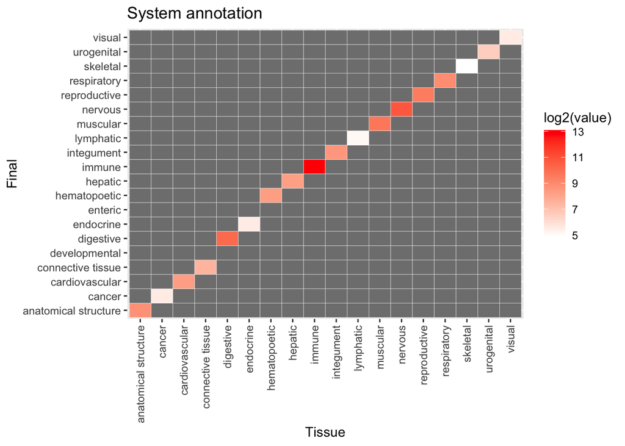

```r
table(allSRAFinal$finalSystem, allSRAFinal$tissueSystem) %>% melt (.) %>%
  ggplot(., aes(Var.2, Var.1)) +
    geom_tile(aes(fill = log2(value)), colour = "white") +
    scale_fill_gradient(low = "white", high = "red") +
    ggtitle("System annotation") +
    xlab("Tissue") +
    ylab("Final") +
    theme(axis.text.x = element_text(angle = 90, vjust = 0.5, hjust=1))
```

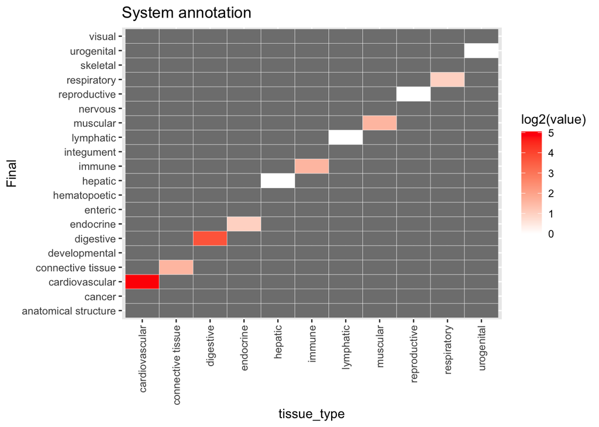

```r
table(allSRAFinal$finalSystem, allSRAFinal$tissue_typeSystem) %>% melt (.) %>%
  ggplot(., aes(Var.2, Var.1)) +
    geom_tile(aes(fill = log2(value)), colour = "white") +
    scale_fill_gradient(low = "white", high = "red") +
    ggtitle("System annotation") +
    xlab("tissue_type") +
    ylab("Final") +
    theme(axis.text.x = element_text(angle = 90, vjust = 0.5, hjust=1))
```

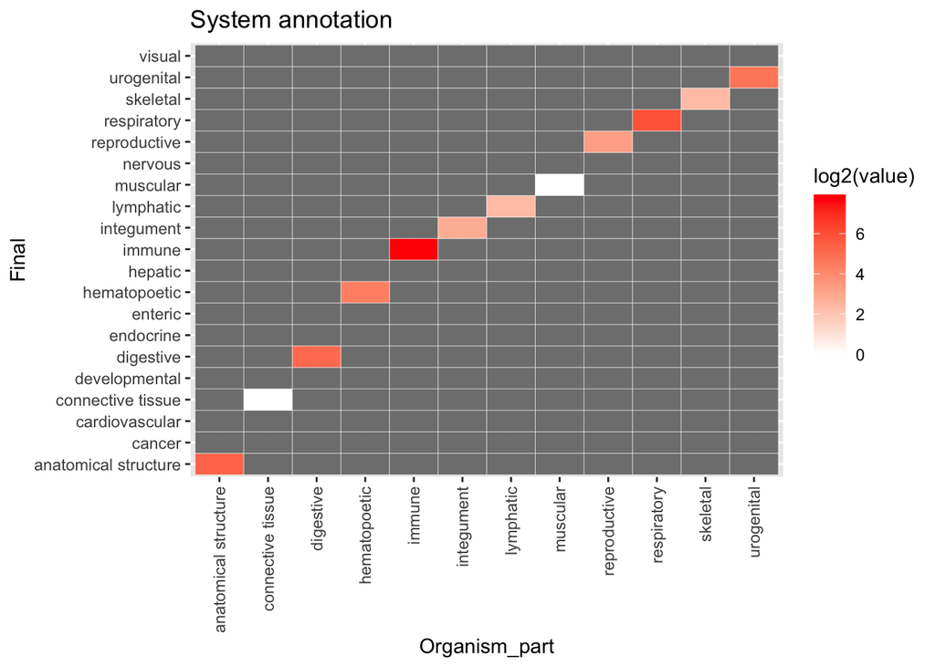

```r
table(allSRAFinal$finalSystem, allSRAFinal$Organism_partSystem) %>% melt (.) %>%
  ggplot(., aes(Var.2, Var.1)) +
    geom_tile(aes(fill = log2(value)), colour = "white") +
    scale_fill_gradient(low = "white", high = "red") +
    ggtitle("System annotation") +
    xlab("Organism_part") +
    ylab("Final") +
    theme(axis.text.x = element_text(angle = 90, vjust = 0.5, hjust=1))
```

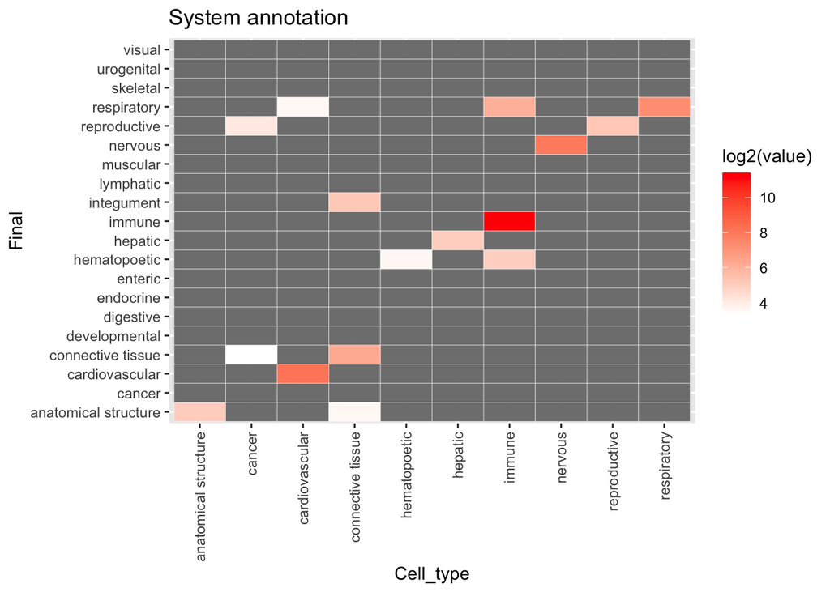

```r
# Yeeeeeep these two are fucked up. Some of it will have been my old approach, but other stuff is gonna be harder to clean up.
table(allSRAFinal$finalSystem, allSRAFinal$Cell_typeSystem) %>% melt (.) %>%
  ggplot(., aes(Var.2, Var.1)) +
    geom_tile(aes(fill = log2(value)), colour = "white") +
    scale_fill_gradient(low = "white", high = "red") +
    ggtitle("System annotation") +
    xlab("Cell_type") +
    ylab("Final") +
    theme(axis.text.x = element_text(angle = 90, vjust = 0.5, hjust=1))
```

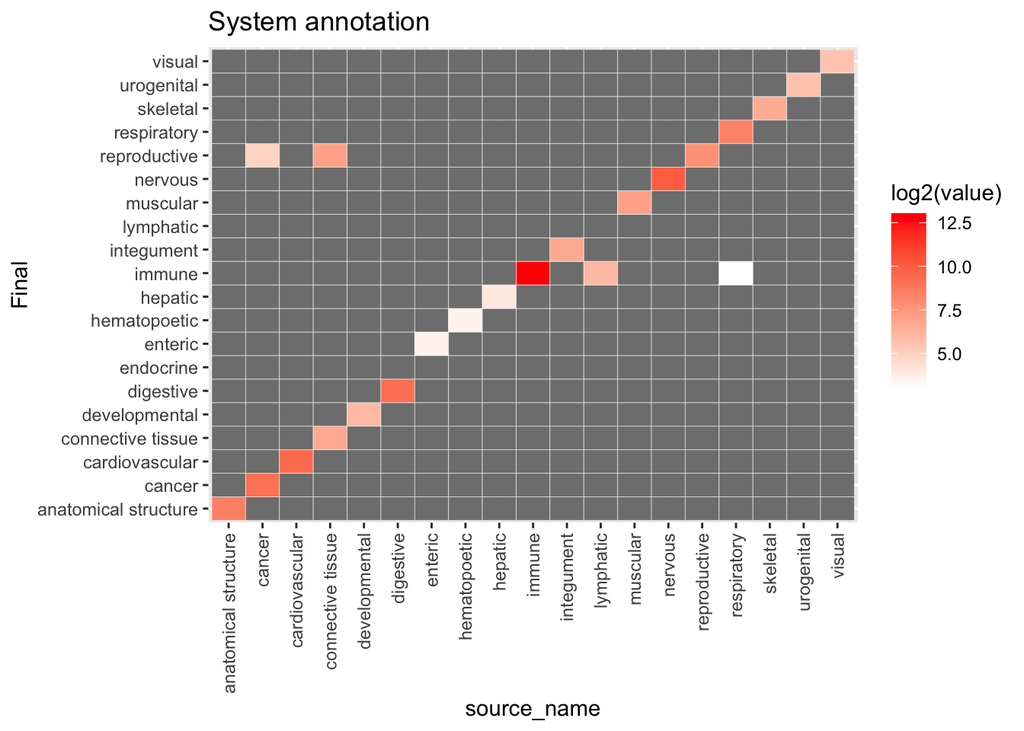

```r
table(allSRAFinal$finalSystem, allSRAFinal$source_nameSystem) %>% melt (.) %>%
  ggplot(., aes(Var.2, Var.1)) +
    geom_tile(aes(fill = log2(value)), colour = "white") +
    scale_fill_gradient(low = "white", high = "red") +
    ggtitle("System annotation") +
    xlab("source_name") +
    ylab("Final") +
    theme(axis.text.x = element_text(angle = 90, vjust = 0.5, hjust=1))
```

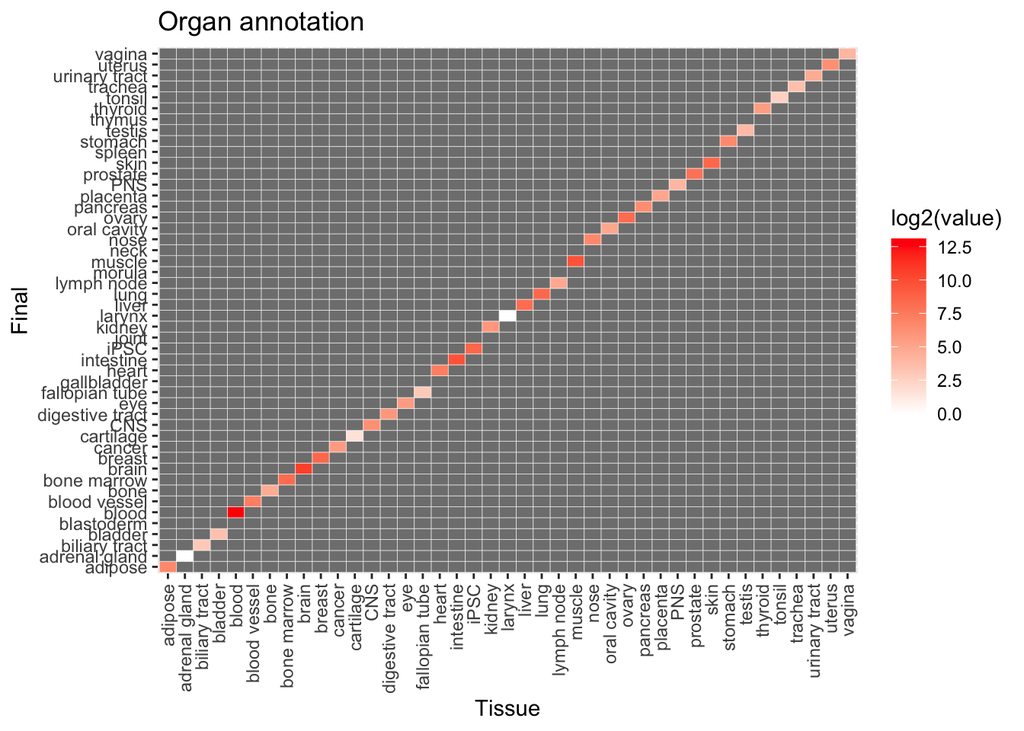

```r
# And now same for organs:
table(allSRAFinal$finalOrgan, allSRAFinal$tissueOrgan) %>% melt (.) %>%
  ggplot(., aes(Var.2, Var.1)) +
    geom_tile(aes(fill = log2(value)), colour = "white") +
    scale_fill_gradient(low = "white", high = "red") +
    ggtitle("Organ annotation") +
    xlab("Tissue") +
    ylab("Final") +
    theme(axis.text.x = element_text(angle = 90, vjust = 0.5, hjust=1))
```

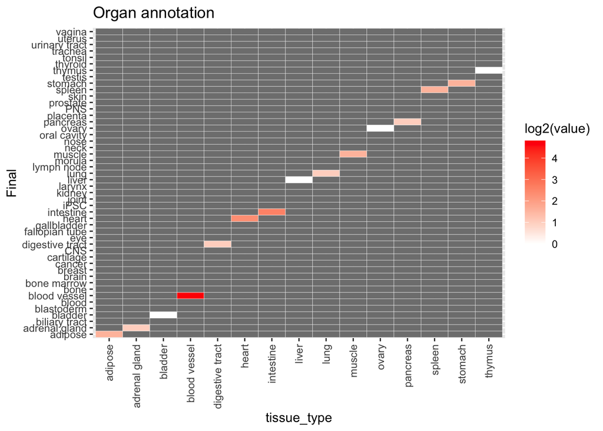

```r
table(allSRAFinal$finalOrgan, allSRAFinal$tissue_typeOrgan) %>% melt (.) %>%
  ggplot(., aes(Var.2, Var.1)) +
    geom_tile(aes(fill = log2(value)), colour = "white") +
    scale_fill_gradient(low = "white", high = "red") +
    ggtitle("Organ annotation") +
    xlab("tissue_type") +
    ylab("Final") +
    theme(axis.text.x = element_text(angle = 90, vjust = 0.5, hjust=1))
```

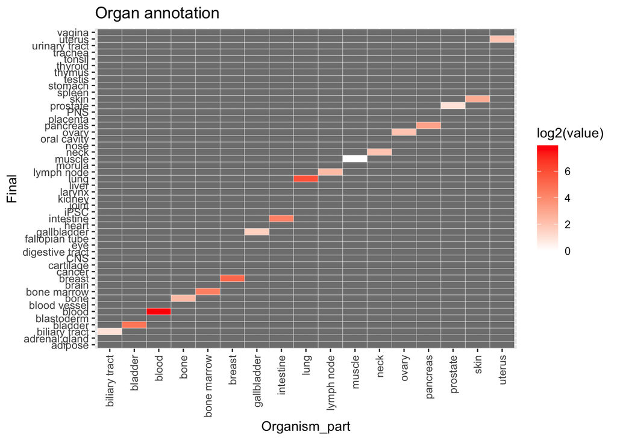

```r
table(allSRAFinal$finalOrgan, allSRAFinal$Organism_partOrgan) %>% melt (.) %>%
  ggplot(., aes(Var.2, Var.1)) +
    geom_tile(aes(fill = log2(value)), colour = "white") +
    scale_fill_gradient(low = "white", high = "red") +
    ggtitle("Organ annotation") +
    xlab("Organism_part") +
    ylab("Final") +
    theme(axis.text.x = element_text(angle = 90, vjust = 0.5, hjust=1))
```

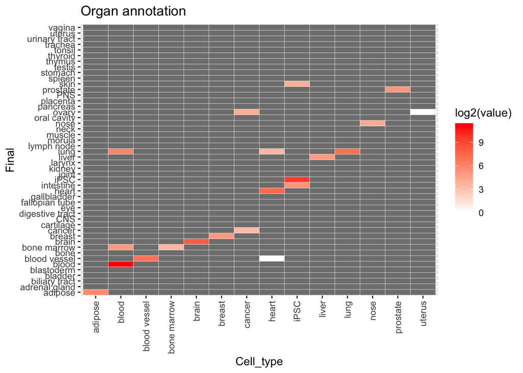

```r
# Yeeeeeep these two are fucked up. Some of it will have been my old approach, but other stuff is gonna be harder to clean up.
table(allSRAFinal$finalOrgan, allSRAFinal$Cell_typeOrgan) %>% melt (.) %>%
  ggplot(., aes(Var.2, Var.1)) +
    geom_tile(aes(fill = log2(value)), colour = "white") +
    scale_fill_gradient(low = "white", high = "red") +
    ggtitle("Organ annotation") +
    xlab("Cell_type") +
    ylab("Final") +
    theme(axis.text.x = element_text(angle = 90, vjust = 0.5, hjust=1))
```

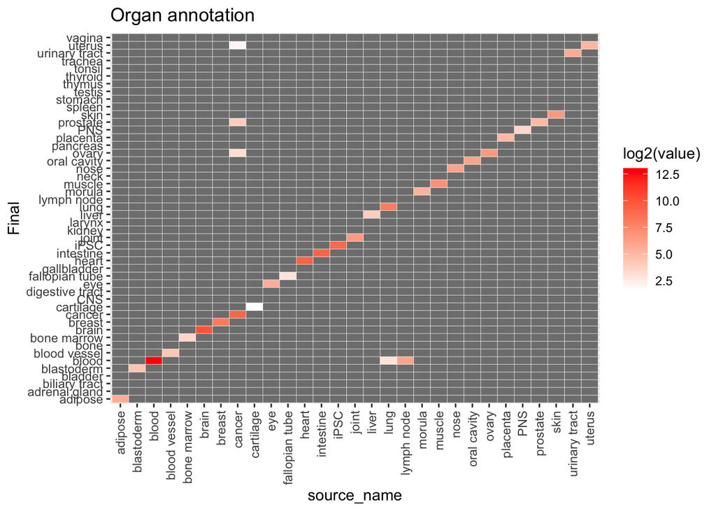

```r
table(allSRAFinal$finalOrgan, allSRAFinal$source_nameOrgan) %>% melt (.) %>%
  ggplot(., aes(Var.2, Var.1)) +
    geom_tile(aes(fill = log2(value)), colour = "white") +
    scale_fill_gradient(low = "white", high = "red") +
    ggtitle("Organ annotation") +
    xlab("source_name") +
    ylab("Final") +
    theme(axis.text.x = element_text(angle = 90, vjust = 0.5, hjust=1))
```

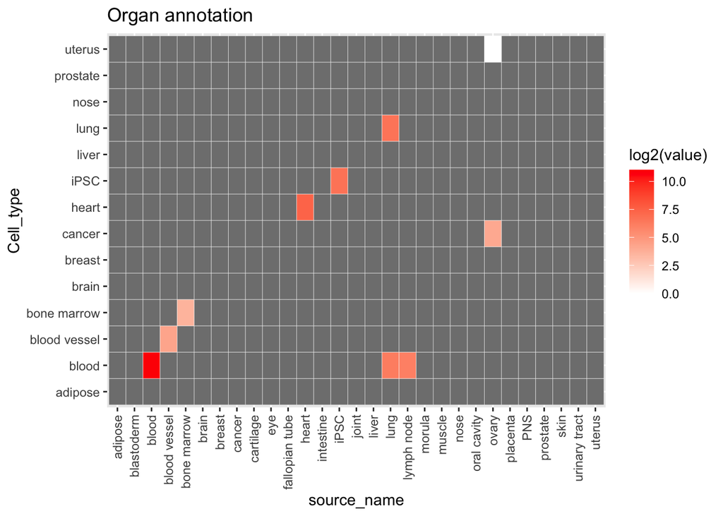

```r
# How often do these two agree?
table(allSRAFinal$Cell_typeOrgan, allSRAFinal$source_nameOrgan) %>% melt (.) %>%
  ggplot(., aes(Var.2, Var.1)) +
    geom_tile(aes(fill = log2(value)), colour = "white") +
    scale_fill_gradient(low = "white", high = "red") +
    ggtitle("Organ annotation") +
    xlab("source_name") +
    ylab("Cell_type") +
    theme(axis.text.x = element_text(angle = 90, vjust = 0.5, hjust=1))
```

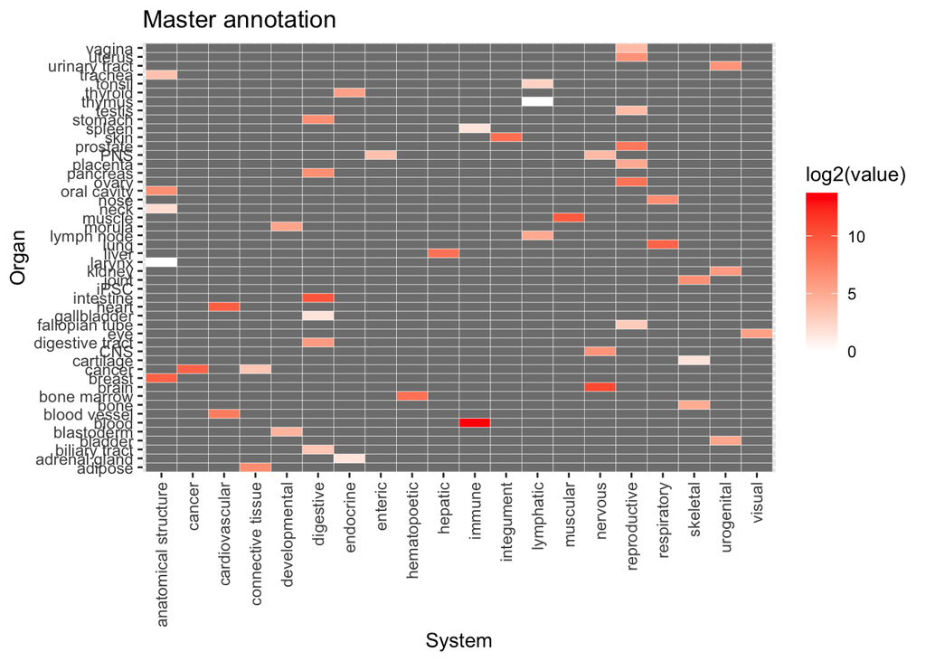

```r
# How often do these two agree?
table(allSRAFinal$finalOrgan, allSRAFinal$finalSystem) %>% melt (.) %>%
  ggplot(., aes(Var.2, Var.1)) +
    geom_tile(aes(fill = log2(value)), colour = "white") +
    scale_fill_gradient(low = "white", high = "red") +
    ggtitle("Master annotation") +
    xlab("System") +
    ylab("Organ") +
    theme(axis.text.x = element_text(angle = 90, vjust = 0.5, hjust=1))
```

```r
# Let's look only at the discrepancies... write a little function to show us because otherwise it gets annoying
seeMismatches <- function(Var1, Var2){
  messySubset <- allSRAFinal[allSRAFinal[[Var1]] != allSRAFinal[[Var2]],] %>% .[!is.na(.[[Var2]]),]
  return(messySubset)
  }

cellOrganMismatches <- seeMismatches("finalOrgan", "Cell_typeOrgan")
cellSystemMismatches <- seeMismatches("finalSystem", "Cell_typeSystem")
sourceOrganMismatches <- seeMismatches("finalOrgan", "source_nameOrgan")
sourceSystemMismatches <- seeMismatches("finalSystem", "source_nameSystem")

table(cellOrganMismatches$finalOrgan, cellOrganMismatches$Cell_typeOrgan)
```

```
##
##                blood cancer heart iPSC uterus
##   blood vessel     0      0     1    0      0
##   bone marrow     31      0     0    0      0
##   intestine        0      0     0   39      0
##   lung            66      0    12    0      0
##   ovary            0     17     0    0      1
##   skin             0      0     0   15      0
```

```r
table(cellSystemMismatches$finalSystem, cellSystemMismatches$Cell_typeSystem)
```

```
##
##                        cancer cardiovascular connective tissue immune
##   anatomical structure      0              0                12      0
##   connective tissue        10              0                 0      0
##   hematopoetic              0              0                 0     31
##   integument                0              0                36      0
##   reproductive             17              0                 0      0
##   respiratory               0             12                 0     66
```

```r
table(sourceOrganMismatches$finalOrgan, sourceOrganMismatches$source_nameOrgan)
```

```
##
##            cancer lung lymph node
##   blood         0    8         66
##   ovary         9    0          0
##   prostate     16    0          0
##   uterus        4    0          0
```

```r
table(sourceSystemMismatches$finalSystem, sourceSystemMismatches$source_nameSystem)
```

```
##
##                cancer connective tissue lymphatic respiratory
##   immune            0                 0        66           8
##   reproductive     29               129         0           0
```

```r
# Make my life easier
columnsILike <- c(1:3, 6,7,8,13,26,29,44,45,49,50,51,52)

# by(cellOrganMismatches, c(cellOrganMismatches$finalOrgan), function(x) head(x[,columnsILike], n = 20))
# by(cellSystemMismatches, c(cellSystemMismatches$Cell_typeSystem), function(x) head(x[,columnsILike], n = 20))
# by(sourceOrganMismatches, c(sourceOrganMismatches$finalOrgan), function(x) head(x[,columnsILike], n = 20))
# by(sourceSystemMismatches, c(sourceSystemMismatches$finalSystem), function(x) head(x[,columnsILike], n = 20))

table(cellOrganMismatches$SRA.Study)
```

```
##
## DRP001797 SRP221289 SRP221290 SRP223239 SRP259538 SRP266877 SRP310133 SRP328303 SRP362734
##         1         8        10        66        12        15        20        11        39
```

```r
table(cellSystemMismatches$SRA.Study)
```

```
##
## SRP070663 SRP125571 SRP219483 SRP220383 SRP221289 SRP221290 SRP223239 SRP259538 SRP310133 SRP328303
##         4        24        10        10         7        20        66        12        20        11
```

```r
table(sourceOrganMismatches$SRA.Study)
```

```
##
## SRP118614 SRP223239 SRP290921 SRP352989
##        16        66        13         8
```

```r
table(sourceSystemMismatches$SRA.Study)
```

```
##
## SRP118614 SRP223239 SRP225709 SRP290921 SRP352989
##        16        66       129        13         8
```

```r
# by(cellOrganMismatches, c(cellOrganMismatches$SRA.Study), function(x) head(x[,columnsILike], n = 20))
# by(cellSystemMismatches, c(cellSystemMismatches$SRA.Study), function(x) head(x[,columnsILike], n = 20))
# by(sourceOrganMismatches, c(sourceOrganMismatches$SRA.Study), function(x) head(x[,columnsILike], n = 20))
# by(sourceSystemMismatches, c(sourceSystemMismatches$SRA.Study), function(x) head(x[,columnsILike], n = 20))
```

Some of these are clear incorrect assignments when cleaning up the tissue stuff, and so the big spreadsheet needs to be updated, eg, the foreskin fibroblasts from Coriell which came up as urogenital (SRP070663, now fixed). However, there’s also a lot of problems with samples that do end up in different classes depending of which column one looks at, eg, SRP266877 should really be under iPSC but isn’t because tissue is given as blood, even though it’s an established cell line… Not all the cases are clear cut, and some are straight up contradictory, eg, DRP001797, which says endocardial cells but also endothelium of blood vessels, or, SRP056287, which gives cell type as cortical neurons, and tissue as fibroblast and which seem to be iPSC-derived cortical neurons (updated), or SRP259538, which lists cardiomyocyte and foetal lung (but they’re cell-line derived anyhow)

There’s a lot of immune cells sampled in the lung, and I’m not sure what to do with them - keep them as both things?

So that’s a first pass, but we need to get rid of established cell lines and then come back to some of this. Next, some checks for missingness etc

```r
table(allSRAFinal$finalSystem)
```

```
##
## anatomical structure               cancer       cardiovascular    connective tissue        developmental            digestive            endocrine              enteric
##                  771                  622                  988                  221                   63                 1307                   49                   12
##         hematopoetic              hepatic               immune           integument            lymphatic             muscular              nervous         reproductive
##                  353                  330                13588                  399                   40                  823                 1783                  727
##          respiratory             skeletal           urogenital               visual
##                  682                  126                  175                   47
```

```r
table(allSRAFinal$finalOrgan)
```

```
##
##         adipose   adrenal gland   biliary tract         bladder      blastoderm           blood    blood vessel            bone     bone marrow           brain          breast
##             107               3              10              38              22           13585             214              31             353            1688             657
##          cancer       cartilage             CNS digestive tract             eye  fallopian tube     gallbladder           heart       intestine            iPSC           joint
##             632               3              79              59              47               8               3             774            1036            1453              92
##          kidney          larynx           liver            lung      lymph node          morula          muscle            neck            nose     oral cavity           ovary
##              59               1             330             576              33              41             823               4             106              97             321
##        pancreas        placenta             PNS        prostate            skin          spleen         stomach          testis          thymus         thyroid          tonsil
##              98              32              28             253             399               3             101              15               1              46               6
##         trachea   urinary tract          uterus          vagina
##              12              78              82              16
```

```r
table(is.na(allSRAFinal$finalSystem), is.na(allSRAFinal$finalOrgan))
```

```
##
##         FALSE  TRUE
##   FALSE 23002   104
##   TRUE   1453   689
```

```r
table(is.na(allSRAFinal$finalSystem))
```

```
##
## FALSE  TRUE
## 23106  2142
```

```r
table(is.na(allSRAFinal$finalOrgan))
```

```
##
## FALSE  TRUE
## 24455   793
```

```r
noAssignment <- allSRAFinal[is.na(allSRAFinal$finalOrgan) & is.na(allSRAFinal$finalSystem),]
table(noAssignment$SRA.Study)
```

```
##
## DRP001150 ERP001942 ERP122083 ERP122103 ERP122256 SRP151215 SRP179998 SRP181649 SRP186687 SRP343308 SRP344328
##         1       464         6         1         5        25        15        15        19       124        14
```

```r
# by(noAssignment, noAssignment$SRA.Study, function(x) head(x))
```

Most of these had info in one of the tissue columns, but sometimes I had to go back to run selector and dig a bit deeper.

- DRP001150: cell mixture - tissue sample (yikes): no fix, will get dropped
- ERP001942: LCLs
- ERP122083: more cancer: finalOrgan:cancer and finalTissue:cancer
- ERP122103: single cancer sample: finalOrgan:cancer and finalTissue:cancer
- ERP122256: soft tissue cancer: finalOrgan:cancer and finalTissue:cancer
- SRP151215: LCLs
- SRP179998: brain sample that for some reason isn’t matching well: finalOrgan:brain and finalSystem:nervous
- SRP181079: BCR sequencing of B-cells; finalOrgan:blood and finalSystem:immune
- SRP181649: single established cell line: no fix, will get dropped
- SRP186687: established cancer cell lines: no fix, will get dropped
- SRP343308: Intestinal biopsies from multiple tissues: finalOrgan:intestine and finalSystem:digestive
- SRP344328: Intrahepatic cholangiocarcinoma: finalOrgan: liver and finalSystem:hepatic

```r
# What are the NAs...? 464 Of them are the LCL study, so let's fix that, first of all:
allSRAFinal[allSRAFinal$SRA.Study %in% c("ERP001942", "SRP151215", "SRP181079"),]$finalSystem <- "immune"
allSRAFinal[allSRAFinal$SRA.Study %in% c("ERP001942", "SRP151215", "SRP181079"),]$finalOrgan <- "blood"

allSRAFinal[allSRAFinal$SRA.Study %in% c("ERP122083", "ERP122103", "ERP122256"),]$finalSystem <- "cancer"
allSRAFinal[allSRAFinal$SRA.Study %in% c("ERP122083", "ERP122103", "ERP122256"),]$finalOrgan <- "cancer"

allSRAFinal[allSRAFinal$SRA.Study %in% "SRP344328",]$finalSystem <- "hepatic"
allSRAFinal[allSRAFinal$SRA.Study %in% "SRP344328",]$finalOrgan <- "liver"

allSRAFinal[allSRAFinal$SRA.Study %in% "SRP343308",]$finalSystem <- "digestive"
allSRAFinal[allSRAFinal$SRA.Study %in% "SRP343308",]$finalOrgan <- "intestine"

allSRAFinal[allSRAFinal$SRA.Study %in% "SRP179998",]$finalSystem <- "nervous"
allSRAFinal[allSRAFinal$SRA.Study %in% "SRP179998",]$finalOrgan <- "brain"

noAssignment <- allSRAFinal[is.na(allSRAFinal$finalOrgan) & is.na(allSRAFinal$finalSystem),]
table(noAssignment$SRA.Study)
```

```
##
## DRP001150 SRP181649 SRP186687
##         1        15        19
```

```r
# by(noAssignment, noAssignment$SRA.Study, function(x) head(x))

# Remove that mixed tissue one.
allSRAFinal <- allSRAFinal[!(allSRAFinal$SRA.Study %in% "DRP001150"),]

rm(noAssignment)
```

Much better… so we’ve resolved the NAs, but not the tissue ambiguities, which I think might just have to stay as is.

Now we look at the rows with info encoded in the `Cell_line` column, in addition to our organ and tissue assignments. Lots of these are cell lines that have ancestry info, but are established/immortalised, which was not included in our initial search… but should it have been? A key culprit is SRP186687, which is almost 1000 cancer samples with sequencing.

The brutal approach is to simply remove the entire study, and then come back again. But it would be smarter to also whitelist some terms and not just remove the column, or remove any rows with info in the column. SRP347253 has some epic cell line names, for instance, and all the occurrences of LCL etc should be kept - but first gotta check they’re not already covered in other columns!

```r
table(!is.na(allSRAFinal$Cell_line))
```

```
##
## FALSE  TRUE
## 22873  2374
```

```r
allCellLine <- allSRAFinal[!is.na(allSRAFinal$Cell_line),]
sort(table(allCellLine$SRA.Study), decreasing=T)
```

```
##
## SRP186687 SRP347253 ERP114122 SRP344545 SRP132693 SRP154009 SRP323748 SRP362734 SRP106527 SRP217300 SRP090531 SRP125571 SRP151215 SRP103111 SRP174206 SRP223674 SRP330940 SRP221374
##       979       304       159       108        91        44        40        39        30        30        29        28        25        24        24        24        24        23
## SRP075592 SRP237644 SRP408226 SRP292295 SRP191042 SRP222944 SRP292536 SRP056109 SRP073347 SRP367525 SRP266877 SRP269147 SRP155367 SRP178235 SRP179498 SRP193979 SRP259538 SRP334792
##        21        21        20        19        18        18        18        16        16        16        15        14        12        12        12        12        12        12
## SRP352928 SRP131505 SRP198410 SRP219483 SRP220383 SRP220267 SRP070663 SRP181649
##        12        10        10        10        10         6         4         3
```

```r
head(sort(table(allCellLine$Cell_line), decreasing=T), n =50) # Some of these are clear keepers, some of the are clear removal. But the question is which is which, and how do I make my life easier? Let's check the big ones first:
```

```
##
##                     lymphoblastoid cell line                                     organoid                                       raisin                                         PBMC
##                                          159                                           39                                           36                                           26
##                                        HBMEC             lymphoblastoid cell lines (LCLs)                                         MCF7                                motor neurons
##                                           25                                           25                                           25                                           24
##                      PC-3 (ATCC\\, CRL-1435)                                 B lymphocyte                                       SKOV-3                                          AGS
##                                           24                                           23                                           21                                           20
##                                        HepG2                                   MDA-MB-231                                       PANC-1             primary vaginal epithelial cells
##                                           20                                           19                                           17                                           16
##                                       WTC-11                                       merlot                                       butter                                          sun
##                                           15                                           14                                           13                                           13
##                     HB-8065 (Hep G2) [HEPG2]                    hiPSC-derived trophoblast                 IMR90-derived cardiomyocytes primarily peripheral blood mononuclear cells
##                                           12                                           12                                           12                                           12
##                                WC-24-02-DS-B                                WC-24-02-DS-M                                        dijon                                        lilac
##                                           12                                           12                                           11                                           11
##                                       violet                                         corn                                       EFO-21                                   fibroblast
##                                           11                                           10                                           10                                           10
##                                        grape                                       HDLM-2                                   MDA-MB-468                                       orchid
##                                           10                                           10                                           10                                           10
##                                        23555                                        28815                                        apple                                  fibroblasts
##                                            9                                            9                                            9                                            9
##                                        honey                                        21792                                        27322                                        29089
##                                            9                                            8                                            8                                            8
##                                         A549                                       coffee                                       H21792                                       H25237
##                                            8                                            8                                            8                                            8
##                                       H28815                                         iris
##                                            8                                            8
```

```r
# by(allCellLine, allCellLine$SRA.Study, function(x) sort(table(x$finalOrgan),  decreasing=T))
# by(allCellLine, allCellLine$SRA.Study, function(x) sort(table(x$finalSystem),  decreasing=T))
# by(allCellLine, allCellLine$SRA.Study, function(x) sort(table(x$Cell_line),  decreasing=T))
# by(allCellLine, allCellLine$SRA.Study, function(x) head(x[,columnsILike], n=20))
rm(allCellLine)
```

Let’s organise this a bit:

### Studies to exclude:

- SRP186687: the huge cancer study, currently assigned to various organs and lots of NA. exclude.
- SRP217300: MIA PaCa, established breast cancer cell line. exclude.
- SRP090531: mix of established cell lines and lines that closely match other cellosaurus IDs. exclude.
- SRP103111: PC-3. established. exclude.
- SRP075592: established. exclude.
- SRP237644: established. exclude.
- SRP408226: HepG2. exclude.
- SRP292295: established cell line. exclude.
- SRP191042: established. exclude.
- SRP292536: established cancer cell lines. exclude.
- SRP056109: established cancer cell line. exclude.
- SRP269147: established cancer cell lines. exclude.
- SRP178235: established. exclude.
- SRP179498: established. exclude.
- SRP193979: HepG2. exclude.
- SRP259538: established cell line. exclude.
- SRP334792: prostate cancer cell lines from ATCC. exclude.
- SRP131505: established cancer cell lines. exclude.
- SRP091668: established. exclude.
- SRP041840: established. exclude.
- SRP057446: HepG2 and related. exclude.
- SRP060253: AGS. exclude.
- SRP194087: established. exclude.
- SRP220267: Caco2. exclude.
- SRP066625: HL-60/S4. exclude
- SRP181649: Huh-7. exclude.
- SRP298738: established AML cell line. exclude.
- SRP074707: established. exclude.
- SRP111915: established. exclude.
- SRP164930: established. exclude.

### Studies to keep:

These are mostly iPSCs and derivatives, so not too sure what to do with them:

- SRP347253: the big iPSC panel, correctly assigned to iPSCs. ok
- SRP132693: iPSC, iPSC derived cardiomyocytes and primary heart tissue. correctly labelled. ok.
- SRP154009: iPSC and iPSC derived cardiomyocytes. correctly labelled. ok
- SRP323748: SRA accession says they’re all iPSC derived cardiomyocytes from iPSCore, and this is recorded in the ‘cell_subtype’ column. need to update. Unsure.
- SRP362734: colorectal cancer organoids… currently processed as if colorectal. need to update. unsure.
- SRP125571: iPSC-derived cortical neurons (in `Sample_type`) from coriell fibroblasts. need to update. unsure.
- SRP223674: iPSC-derived motor neurons, incorrectly labelled as blood (starting material). need to update. unsure.
- SRP330940: iPSCs and iPSC-derived material from publicly available line. unsure.
- SRP222944: iPSC-derived tissues, labelled as peripheral blood. need to update. unsure.
- SRP266877: WTC-11 iPSC cell line. need to update. unsure.
- SRP155367: iPSC and iPSC derived material. SRA says from Coriell, but neither cellosaurus nor coriell have heard of this. unsure.
- SRP070663: Coriell cell lines and iPSCs from them, correctly assigned. unsure.

# These are easy to justify keeping:

- ERP114122: LCLs, (from 1000 Genomes). ok
- SRP344545: LCLs, (from 1000 Genomes). ok
- SRP106527: CEU LCL sequencing. ok
- SRP151215: LCLs. ok.
- SRP174206: primary samples, contain solid info in tissue column (tho I’m still sus but…). ok.
- SRP221374: blood cells. ok.
- SRP073347: PBMCs. ok.
- SRP367525: primary vaginal samples. ok.
- SRP352928: PBMCs. ok.
- SRP198410: PBMCs. ok.
- SRP219483: primary cell lines. ok.
- SRP220383: primary cell lines. ok.
- SRP052896: primary samples. ok.

So that’s a quick summary. Let’s clean this up and then check out what happens with all of those disagreements from before; this has also identified a few that need to be updated:

```r
# First we make a list of a lot of studies to exclude:
establishedStudies <- c("SRP164930", "SRP111915", "SRP074707", "SRP298738", "SRP181649", "SRP066625", "SRP220267", "SRP194087", "SRP060253", "SRP057446", "SRP041840", "SRP091668", "SRP131505", "SRP334792", "SRP259538", "SRP193979", "SRP179498", "SRP178235", "SRP269147", "SRP056109", "SRP292536", "SRP191042", "SRP292295", "SRP408226", "SRP237644", "SRP075592", "SRP103111", "SRP090531", "SRP217300", "SRP186687")

allSRAFinal <- allSRAFinal[!(allSRAFinal$SRA.Study %in% establishedStudies),]
dim(allSRAFinal) # Looks better
```

```
## [1] 23935    48
```

```r
# Then we gotta make sure all the other tissue assignments are ok:
allCellLine <- allSRAFinal[allSRAFinal$SRA.Study %in% allSRAFinal[!is.na(allSRAFinal$Cell_line),]$SRA.Study,] # Yes again
by(allCellLine, allCellLine$SRA.Study, function(x) sort(table(x$finalOrgan),  decreasing=T))
```

```
## allCellLine$SRA.Study: ERP114122
## blood
##   159
## ---------------------------------------------------------------------------------------------------------------------------------------
## allCellLine$SRA.Study: SRP070663
##
## iPSC skin
##    8    4
## ---------------------------------------------------------------------------------------------------------------------------------------
## allCellLine$SRA.Study: SRP073347
## blood
##    16
## ---------------------------------------------------------------------------------------------------------------------------------------
## allCellLine$SRA.Study: SRP106527
## blood
##    30
## ---------------------------------------------------------------------------------------------------------------------------------------
## allCellLine$SRA.Study: SRP125571
##
## oral cavity        skin
##          12          12
## ---------------------------------------------------------------------------------------------------------------------------------------
## allCellLine$SRA.Study: SRP132693
##
##  iPSC heart
##    69    22
## ---------------------------------------------------------------------------------------------------------------------------------------
## allCellLine$SRA.Study: SRP151215
## blood
##    25
## ---------------------------------------------------------------------------------------------------------------------------------------
## allCellLine$SRA.Study: SRP154009
## iPSC
##   44
## ---------------------------------------------------------------------------------------------------------------------------------------
## allCellLine$SRA.Study: SRP155367
## iPSC
##   12
## ---------------------------------------------------------------------------------------------------------------------------------------
## allCellLine$SRA.Study: SRP174206
```

[output cut: 46 more lines]

```
## allCellLine$SRA.Study: SRP347253
## iPSC
##  304
## ---------------------------------------------------------------------------------------------------------------------------------------
## allCellLine$SRA.Study: SRP352928
## blood
##    12
## ---------------------------------------------------------------------------------------------------------------------------------------
## allCellLine$SRA.Study: SRP362734
## intestine
##        39
## ---------------------------------------------------------------------------------------------------------------------------------------
## allCellLine$SRA.Study: SRP367525
## vagina
##     16
```

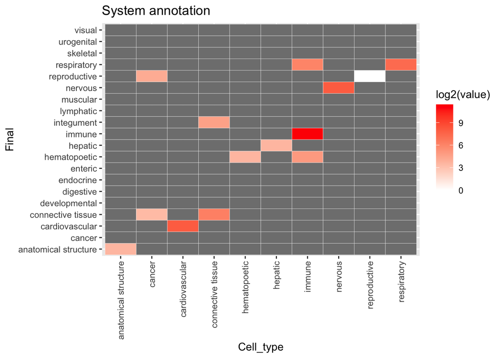

```r
# Some more updates...
allSRAFinal[allSRAFinal$SRA.Study %in% c("SRP362734", "SRP323748", "SRP266877", "SRP223674", "SRP222944", "SRP125571"),]$finalSystem <- NA
allSRAFinal[allSRAFinal$SRA.Study %in% c("SRP362734", "SRP323748", "SRP266877", "SRP223674", "SRP222944", "SRP125571"),]$finalOrgan <- "iPSC"

# I guess we could make all the plots again... but easier to just tally disagreements?
table(allSRAFinal$finalSystem, allSRAFinal$Cell_typeSystem) %>% melt (.) %>%
  ggplot(., aes(Var.2, Var.1)) +
    geom_tile(aes(fill = log2(value)), colour = "white") +
    scale_fill_gradient(low = "white", high = "red") +
    ggtitle("System annotation") +
    xlab("Cell_type") +
    ylab("Final") +
    theme(axis.text.x = element_text(angle = 90, vjust = 0.5, hjust=1))
```

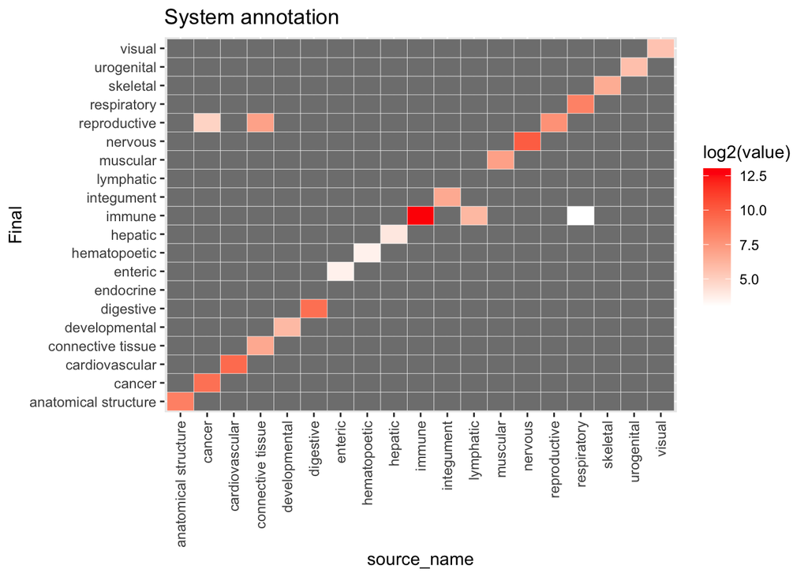

```r
table(allSRAFinal$finalSystem, allSRAFinal$source_nameSystem) %>% melt (.) %>%
  ggplot(., aes(Var.2, Var.1)) +
    geom_tile(aes(fill = log2(value)), colour = "white") +
    scale_fill_gradient(low = "white", high = "red") +
    ggtitle("System annotation") +
    xlab("source_name") +
    ylab("Final") +
    theme(axis.text.x = element_text(angle = 90, vjust = 0.5, hjust=1))
```

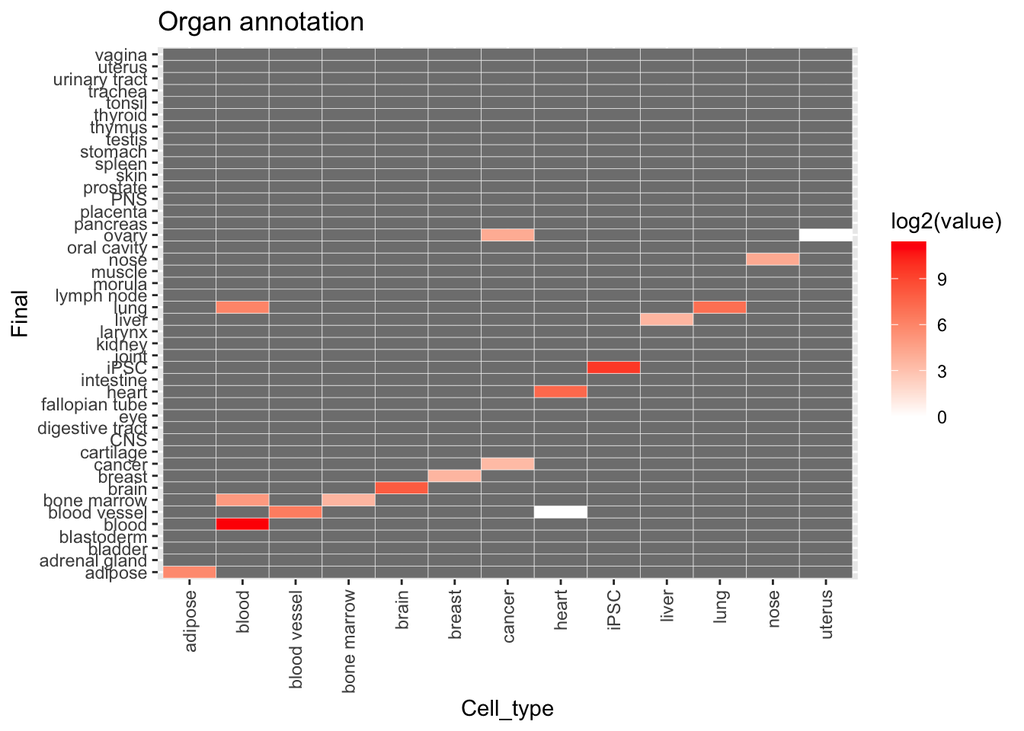

```r
# And now same for organs:
table(allSRAFinal$finalOrgan, allSRAFinal$Cell_typeOrgan) %>% melt (.) %>%
  ggplot(., aes(Var.2, Var.1)) +
    geom_tile(aes(fill = log2(value)), colour = "white") +
    scale_fill_gradient(low = "white", high = "red") +
    ggtitle("Organ annotation") +
    xlab("Cell_type") +
    ylab("Final") +
    theme(axis.text.x = element_text(angle = 90, vjust = 0.5, hjust=1))
```

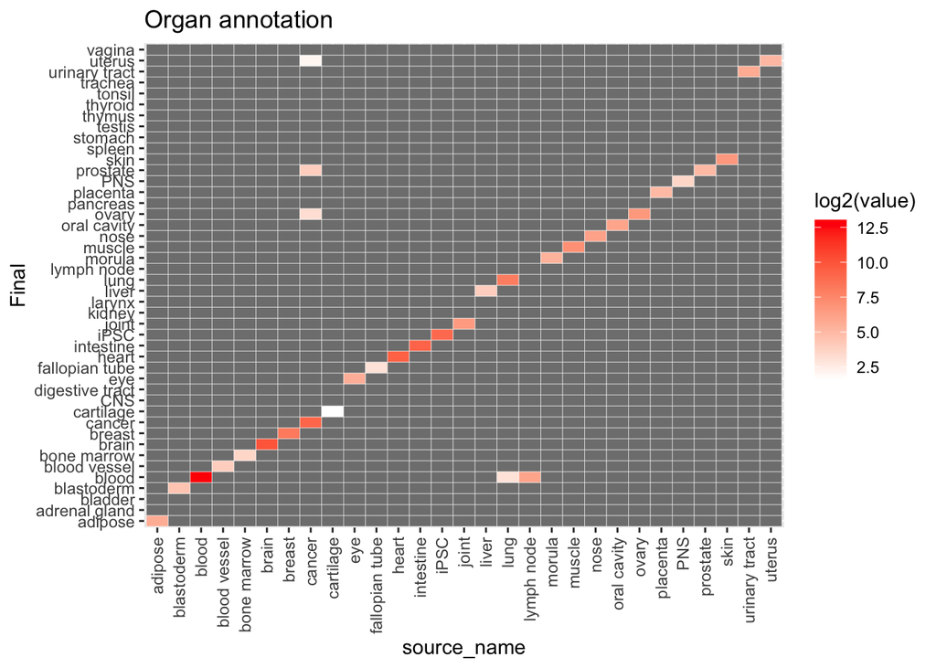

```r
table(allSRAFinal$finalOrgan, allSRAFinal$source_nameOrgan) %>% melt (.) %>%
  ggplot(., aes(Var.2, Var.1)) +
    geom_tile(aes(fill = log2(value)), colour = "white") +
    scale_fill_gradient(low = "white", high = "red") +
    ggtitle("Organ annotation") +
    xlab("source_name") +
    ylab("Final") +
    theme(axis.text.x = element_text(angle = 90, vjust = 0.5, hjust=1))
```

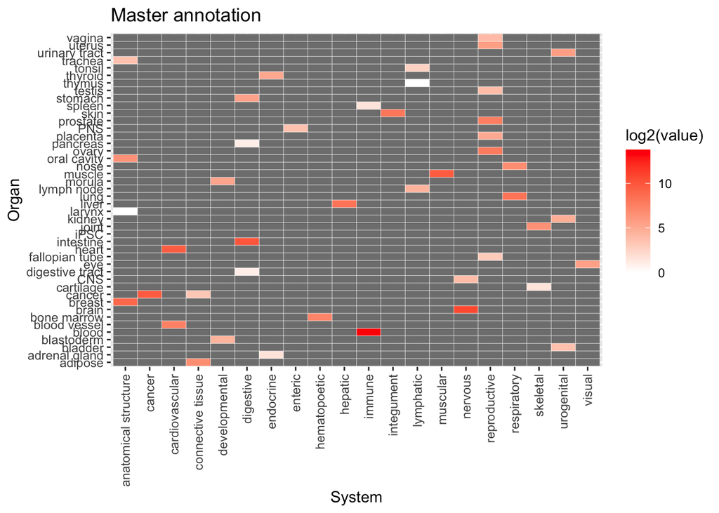

```r
# And the final table... this should be messy, but there should be some sanity to it.
table(allSRAFinal$finalOrgan, allSRAFinal$finalSystem) %>% melt(.) %>%
  ggplot(., aes(Var.2, Var.1)) +
    geom_tile(aes(fill = log2(value)), colour = "white") +
    scale_fill_gradient(low = "white", high = "red") +
    ggtitle("Master annotation") +
    xlab("System") +
    ylab("Organ") +
    theme(axis.text.x = element_text(angle = 90, vjust = 0.5, hjust=1))
```

I think it all looks mostly good now, with the open question of what to do with those where there’s a mismatch between annotation derived from either `Cell_type` or `source_name` and the other columns. It’s not going to make a big difference, I guess, so I think we’re ready to move on to real analyses… let’s just look at things again tho:

```r
dim(allSRAFinal)
```

```
## [1] 23935    48
```

```r
cellOrganMismatches <- seeMismatches("finalOrgan", "Cell_typeOrgan")
cellSystemMismatches <- seeMismatches("finalSystem", "Cell_typeSystem")
sourceOrganMismatches <- seeMismatches("finalOrgan", "source_nameOrgan")
sourceSystemMismatches <- seeMismatches("finalSystem", "source_nameSystem")

table(cellOrganMismatches$finalOrgan, cellOrganMismatches$Cell_typeOrgan)
```

```
##
##                blood cancer heart uterus
##   blood vessel     0      0     1      0
##   bone marrow     31      0     0      0
##   lung            66      0     0      0
##   ovary            0     17     0      1
```

```r
table(cellSystemMismatches$finalSystem, cellSystemMismatches$Cell_typeSystem)
```

```
##
##                     cancer connective tissue immune
##   connective tissue     10                 0      0
##   hematopoetic           0                 0     31
##   integument             0                24      0
##   reproductive          17                 0      0
##   respiratory            0                 0     66
```

```r
table(sourceOrganMismatches$finalOrgan, sourceOrganMismatches$source_nameOrgan)
```

```
##
##            cancer lung lymph node
##   blood         0    8         66
##   ovary         9    0          0
##   prostate     16    0          0
##   uterus        4    0          0
```

```r
table(sourceSystemMismatches$finalSystem, sourceSystemMismatches$source_nameSystem)
```

```
##
##                cancer connective tissue lymphatic respiratory
##   immune            0                 0        66           8
##   reproductive     29               129         0           0
```

```r
table(cellOrganMismatches$SRA.Study)
```

```
##
## DRP001797 SRP221289 SRP221290 SRP223239 SRP310133 SRP328303
##         1         8        10        66        20        11
```

```r
table(cellSystemMismatches$SRA.Study)
```

```
##
## SRP070663 SRP219483 SRP220383 SRP221289 SRP221290 SRP223239 SRP310133 SRP328303
##         4        10        10         7        20        66        20        11
```

```r
table(sourceOrganMismatches$SRA.Study)
```

```
##
## SRP118614 SRP223239 SRP290921 SRP352989
##        16        66        13         8
```

```r
table(sourceSystemMismatches$SRA.Study)
```

```
##
## SRP118614 SRP223239 SRP225709 SRP290921 SRP352989
##        16        66       129        13         8
```

```r
# Yep, not too fussed. So now we can remove some of the temp columns and write this out
allSRAFinal <- allSRAFinal[,-(37:46)]
saveRDS(allSRAFinal, "20250517_allSRAAncestryTissues.rds")
```

And now my other nemesis… disease state. There’s a lot of cancer info already in there, but what else is there?

```r
# Start by checking the columns where disease status might hide, that we haven't looked at already:
names(allSRAFinal)
head(sort(table(allSRAFinal$disease), decreasing=T), n=20)
head(sort(table(allSRAFinal$disease_state), decreasing=T), n=20)
head(sort(table(allSRAFinal$Diagnosis), decreasing=T), n=20)
head(sort(table(allSRAFinal$clinical_information), decreasing=T), n=20)
head(sort(table(allSRAFinal$health_state), decreasing=T), n=20)
head(sort(table(allSRAFinal$DONOR_HEALTH_STATUS), decreasing=T), n=20)

# All of these make sense except for clinical_information, so... we go back to doing the same stuff we did with the population descriptors.
write.table(as.data.frame(table(allSRAFinal$disease)), file="disease_descriptors_raw.tsv", quote=F, row.names=F, sep="\t")
write.table(as.data.frame(table(allSRAFinal$disease_state)), file="disease_state_descriptors_raw.tsv", quote=F, row.names=F, sep="\t")
write.table(as.data.frame(table(allSRAFinal$Diagnosis)), file="Diagnosis_descriptors_raw.tsv", quote=F, row.names=F, sep="\t")
write.table(as.data.frame(table(allSRAFinal$health_state)), file="health_state_descriptors_raw.tsv", quote=F, row.names=F, sep="\t")
write.table(as.data.frame(table(allSRAFinal$DONOR_HEALTH_STATUS)), file="DONOR_HEALTH_STATUS_descriptors_raw.tsv", quote=F, row.names=F, sep="\t")
```

[output not shown]

And now to check the intersections etc etc…

```r
# First, how independent are all of these:
table(is.na(allSRAFinal$disease))
```

```
##
## FALSE  TRUE
##  3211 20724
```

```r
table(is.na(allSRAFinal$Diagnosis))
```

```
##
## FALSE  TRUE
##   793 23142
```

```r
table(is.na(allSRAFinal$disease_state))
```

```
##
## FALSE  TRUE
##  1475 22460
```

```r
table(is.na(allSRAFinal$health_state))
```

```
##
## FALSE  TRUE
##   625 23310
```

```r
table(is.na(allSRAFinal$DONOR_HEALTH_STATUS))
```

```
##
## FALSE  TRUE
##    37 23898
```

```r
# And now please tell me they don't overlap too much (F/F would be overlap):
table(is.na(allSRAFinal$disease), is.na(allSRAFinal$Diagnosis))
```

```
##
##         FALSE  TRUE
##   FALSE     0  3211
##   TRUE    793 19931
```

```r
table(is.na(allSRAFinal$disease), is.na(allSRAFinal$disease_state))
```

```
##
##         FALSE  TRUE
##   FALSE     0  3211
##   TRUE   1475 19249
```

```r
table(is.na(allSRAFinal$disease), is.na(allSRAFinal$health_state)) # ARGH
```

```
##
##         FALSE  TRUE
##   FALSE   465  2746
##   TRUE    160 20564
```

```r
table(is.na(allSRAFinal$disease), is.na(allSRAFinal$DONOR_HEALTH_STATUS)) #ARGH
```

```
##
##         FALSE  TRUE
##   FALSE    37  3174
##   TRUE      0 20724
```

```r
table(is.na(allSRAFinal$disease_state), is.na(allSRAFinal$Diagnosis))
```

```
##
##         FALSE  TRUE
##   FALSE     0  1475
##   TRUE    793 21667
```

```r
table(is.na(allSRAFinal$disease_state), is.na(allSRAFinal$health_state))
```

```
##
##         FALSE  TRUE
##   FALSE     0  1475
##   TRUE    625 21835
```

```r
table(is.na(allSRAFinal$disease_state), is.na(allSRAFinal$DONOR_HEALTH_STATUS))
```

```
##
##         FALSE  TRUE
##   FALSE     0  1475
##   TRUE     37 22423
```

```r
table(is.na(allSRAFinal$health_state), is.na(allSRAFinal$Diagnosis))
```

```
##
##         FALSE  TRUE
##   FALSE     0   625
##   TRUE    793 22517
```

```r
table(is.na(allSRAFinal$health_state), is.na(allSRAFinal$DONOR_HEALTH_STATUS))
```

```
##
##         FALSE  TRUE
##   FALSE     0   625
##   TRUE     37 23273
```

```r
table(is.na(allSRAFinal$Diagnosis), is.na(allSRAFinal$DONOR_HEALTH_STATUS))
```

```
##
##         FALSE  TRUE
##   FALSE     0   793
##   TRUE     37 23105
```

```r
# Checking the overlaps:
allSRAFinal[!is.na(allSRAFinal$disease) & !is.na(allSRAFinal$DONOR_HEALTH_STATUS),] # DONOR_HEALTH_STATUS wins, so when we coalesce it will go first.
```

```
##        SRA.Study Center.Name    BioSample     Organism  LibrarySource Cell_type Tissue Cell_line                    disease ETHNICITY disease_state Diagnosis     tissue_type
## 306686 SRP000941        UCSD SAMN00847533 Homo sapiens TRANSCRIPTOMIC      <NA>   <NA>      <NA>                       None      <NA>          <NA>      <NA>           Aorta
## 306690 SRP000941        UCSD SAMN00847535 Homo sapiens TRANSCRIPTOMIC      <NA>   <NA>      <NA>                       None      <NA>          <NA>      <NA>       Esophagus
## 306694 SRP000941        UCSD SAMN00847539 Homo sapiens TRANSCRIPTOMIC      <NA>   <NA>      <NA>                       None      <NA>          <NA>      <NA>        Pancreas
## 306698 SRP000941        UCSD SAMN00849925 Homo sapiens TRANSCRIPTOMIC      <NA>   <NA>      <NA>                       None      <NA>          <NA>      <NA> Small Intestine
## 306702 SRP000941        UCSD SAMN00855407 Homo sapiens TRANSCRIPTOMIC      <NA>   <NA>      <NA>                       None      <NA>          <NA>      <NA>   Sigmoid Colon
## 306706 SRP000941        UCSD SAMN00828739 Homo sapiens TRANSCRIPTOMIC      <NA>   <NA>      <NA>                       None      <NA>          <NA>      <NA>   Adrenal Gland
## 306710 SRP000941        UCSD SAMN00847536 Homo sapiens TRANSCRIPTOMIC      <NA>   <NA>      <NA>                       None      <NA>          <NA>      <NA>  Adipose Tissue
## 306714 SRP000941        UCSD SAMN00847541 Homo sapiens TRANSCRIPTOMIC      <NA>   <NA>      <NA>                       None      <NA>          <NA>      <NA>    Right Atrium
## 307245 SRP000941        UCSD SAMN01085432 Homo sapiens TRANSCRIPTOMIC      <NA>   <NA>      <NA>                       None      <NA>          <NA>      <NA>          Thymus
## 307267 SRP000941        UCSD SAMN00847540 Homo sapiens TRANSCRIPTOMIC      <NA>   <NA>      <NA>                       None      <NA>          <NA>      <NA>    Psoas Muscle
## 309399 SRP000941        UCSD SAMN00849926 Homo sapiens TRANSCRIPTOMIC      <NA>   <NA>      <NA> iron deficiency\\, bipolar      <NA>          <NA>      <NA>            Lung
## 309401 SRP000941        UCSD SAMN00849927 Homo sapiens TRANSCRIPTOMIC      <NA>   <NA>      <NA>                       None      <NA>          <NA>      <NA>         Gastric
## 309403 SRP000941        UCSD SAMN00847538 Homo sapiens TRANSCRIPTOMIC      <NA>   <NA>      <NA>                       None      <NA>          <NA>      <NA>  Left Ventricle
## 309405 SRP000941        UCSD SAMN00849928 Homo sapiens TRANSCRIPTOMIC      <NA>   <NA>      <NA>                       None      <NA>          <NA>      <NA> Right Ventricle
```

[output cut: 137 more lines]

```r
allSRAFinal %>% count(disease, health_state) # Disease wins.
```

```
##                                                                                                                                                disease
## 1                                                                                                                                                 ALS8
## 2                                                                                                                                            ALZHEIMER
## 3                                                                                                                          AML not otherwise specified
## 4                                                                                                                         AML with MDS-related changes
## 5                                                                                                                         AML with MDS-related changes
## 6                                                                                                                            AML with MLL rearrangment
## 7                                                                                                                         Acute lymphoblastic leukemia
## 8                                                                                                                                  Alzheimer's disease
## 9                                                                                                                                               Anoxia
## 10                                                                                                             Atherosclerotic coronary artery disease
## 11                                                                                                                                 Atrial Fibrillation
## 12                                                                                                                                           B-ALL NOS
## 13                                                                                                                       B-ALL not otherwise specified
## 14                                                                                                           B-ALL with t(12;21) TEL-AML1 (ETV6-RUNX1)
```

[output cut: 401 more lines]

```r
# Now we update terms:
diseaseTerms <- read.csv("20240624_disease_descriptors.csv")
allSRAFinal$finalDisease <- NA

# The laziest way to deal with the ordering here is to reorder the diseaseTerms file by the order we want:
# Diagnosis, health_state, disease_state, disease, DONOR_HEALTH_STATUS
# That way as we move down it, we'll overwrite previously incorrect assignments:

diseaseTerms$coded.as <- factor(diseaseTerms$coded.as, levels=c("Diagnosis", "health_state", "disease_state", "disease", "DONOR_HEALTH_STATUS"))
diseaseTerms <- diseaseTerms[order(diseaseTerms$coded.as),]

for (i in 1:nrow(diseaseTerms)){
  tryCatch({
  allSRAFinal[allSRAFinal[,as.character(diseaseTerms$coded.as[i])] %in% diseaseTerms$Term[i],]$finalDisease <- diseaseTerms$grouping[i]}, error = function(e) {
    message(sprintf("Error at i = %d: %s", i, e$message))
  })
}
```

```
## Error at i = 8: replacement has 1 row, data has 0
```

```
## Error at i = 9: replacement has 1 row, data has 0
```

```
## Error at i = 45: replacement has 1 row, data has 0
```

```
## Error at i = 95: replacement has 1 row, data has 0
```

```
## Error at i = 172: replacement has 1 row, data has 0
```

```
## Error at i = 173: replacement has 1 row, data has 0
```

```
## Error at i = 206: replacement has 1 row, data has 0
```

```r
# And we mustn't forget to add all the other cancer calls!
allSRAFinal[allSRAFinal$finalOrgan %in% "cancer",]$finalDisease <- "cancer"
table(allSRAFinal$finalDisease)
```

```
##
##      acute trauma        autoimmune             blood            cancer    cardiovascular         endocrine  gastrointestinal  genetic syndrome   healthy control        infectious
##                12               983                25              1624                57                10                 7                57              2050               330
##     integumentary            kidney     mental health         metabolic neurodegenerative      neurological             other      reproductive       respiratory
##                 7                17               465               234               183                14                 9                17               127
```

```r
# Check that this actually worked...
allSRAFinal[!is.na(allSRAFinal$health_state) & !is.na(allSRAFinal$disease),]
```

```
##         SRA.Study                                                                  Center.Name    BioSample     Organism  LibrarySource                                Cell_type
## 98154   DRP001797                                                                     UT_RCAST SAMD00008997 Homo sapiens TRANSCRIPTOMIC   Human Umbilical Vein Endothelial Cells
## 98176   DRP001797                                                                     UT_RCAST SAMD00008990 Homo sapiens TRANSCRIPTOMIC   Human Umbilical Vein Endothelial Cells
## 98394   DRP001797                                                                     UT_RCAST SAMD00020294 Homo sapiens TRANSCRIPTOMIC              Human Common Carotid Artery
## 191026  SRP103099                                                 DANA-FARBER CANCER INSTITUTE SAMN06621785 Homo sapiens TRANSCRIPTOMIC                                     <NA>
## 191046  SRP103099                                                 DANA-FARBER CANCER INSTITUTE SAMN06621787 Homo sapiens TRANSCRIPTOMIC                                     <NA>
## 191048  SRP103099                                                 DANA-FARBER CANCER INSTITUTE SAMN06621786 Homo sapiens TRANSCRIPTOMIC                                     <NA>
## 191058  SRP103099                                                 DANA-FARBER CANCER INSTITUTE SAMN06621865 Homo sapiens TRANSCRIPTOMIC                                     <NA>
## 191064  SRP103099                                                 DANA-FARBER CANCER INSTITUTE SAMN06621864 Homo sapiens TRANSCRIPTOMIC                                     <NA>
## 191077  SRP103099                                                 DANA-FARBER CANCER INSTITUTE SAMN06621841 Homo sapiens TRANSCRIPTOMIC                                     <NA>
## 191081  SRP103099                                                 DANA-FARBER CANCER INSTITUTE SAMN06621866 Homo sapiens TRANSCRIPTOMIC                                     <NA>
## 191093  SRP103099                                                 DANA-FARBER CANCER INSTITUTE SAMN06621852 Homo sapiens TRANSCRIPTOMIC                                     <NA>
## 191637  SRP103099                                                 DANA-FARBER CANCER INSTITUTE SAMN06621861 Homo sapiens TRANSCRIPTOMIC                                     <NA>
## 247860  SRP068551                  THE 2ND AFFILIATED HOSPITAL OF CHONGQING MEDICAL UNIVERSITY SAMN04420085 Homo sapiens TRANSCRIPTOMIC                                     <NA>
## 247861  SRP068551                  THE 2ND AFFILIATED HOSPITAL OF CHONGQING MEDICAL UNIVERSITY SAMN04420084 Homo sapiens TRANSCRIPTOMIC                                     <NA>
```

[output cut: 3247 more lines]

```r
# Yep looks good, now we can really analyse things:
saveRDS(allSRAFinal, "20250517_allSRAAncestryTissuesDisease.rds")
```